# Mid-term project instructions

Author

# 1 Mid-term project GitHub repository URL:

https://github.com/SoilDawg/2024dsa_midproject_group8.git

# 2 Instructions

This file contains both the **instructions** for the mid-term project and placeholders for your code. You are required to use this file to produce code, output, and answers to the questions below.

Besides simply creating output, make sure to interpret the output. You will need to create tables and/or plots to arrive at the answers, and then comment on what you found below it.

To get you setup, you will need to:

- Student #1: create a repository on your GitHub account. You can call this repository “2024dsa_midproject_groupX”, **where X is the number of your group**. Make it public, add a README, add a .gitignore for R.
- Student #1: follow the steps we did in class to start a new RStudio project with version control.
- Student #1: in your computer, create the sub-folders code, data, output, and move your data set into the `data` folder. Also, student 1 moves this current script into the `code` folder. Do a git stage, commit, push.
- Student #1: on GitHub, go the repository settings and invite your partner to be a collaborator in the repository. That will give them push permission.
- Now, both students should clone this repository on their computers like we did in class. Make sure this step works well and that you can pull and push from GitHub.
- Student 2, after cloning, does a git pull to get all these updates on their computer.
- Student 1 and 2 work together to update the README file. README files should explain what the repository is about, the goals of that project, who is working in it, and any other important details you may find.

# 3 Introduction

Describe here the introduction of your problem. Consider this as a shortened version of your paper, where you will briefly discuss in 3-4 paragraphs what is the issue/gap in literature, and how the data you collected will help answer this gap.

Soil nutrient management decisions in grazing lands should account for the preexisting nutrients in the soil and their interaction with soil water depending on drainage class to be economically and environmentally beneficial.Addition of broiler litter and plant residues to soils can elevate soil organic carbon in the long term along with increased nutrient mineralization, immobilization, turnover rates and potential mineralization rates. Information on field scale distribution of soil organic carbon, and mechanisms associated with differences due to contrasting fertilization legacies to deeper soil depths is lacking. Hence measuring loss-on-ignition carbon (LOI) which is a measure of soil organic carbon (0.47*LOI for the soils similar to this study, according to Hendricks et al., 2017) and comparing the LOI carbon vertical distribution through different depths in either BL or Min fertilization legacies would provide crucial information on differences in nutrient management required between the two fertilization legacies. Soil drainage characteristics can influence runoff and leaching losses of soil C and N. Research has shown greater losses of dissolved organic carbon (DOC) and dissolved organic (DON) in poorly draining soils compared to freely draining soils (Ghani et al., 2010). Greater residence time of soil water and greater diffusion of dissolved organic matter into the soil solution in moderately well-drained to poorly drained soil have been re-ported (Ghani et al., 2010). In well-drained soils, this same manuscript reported lower residence time of water in soil pores due to faster drainage and greater protection of soil organic matter where aluminum and iron oxides were present. However, changes from oxic to anoxic environments within soil profile could result in mineralization of organic matter with greater CO2 production mediated by Fe-reduction (Chen et al., 2020). The drainage class of soils is crucial in determining better grazing management decisions due to its influence on organic matter decomposition and nutrient cycling mechanisms.

# 4 Hypothesis and objectives

Hypothesis: LOI carbon concentrations in soils to a depth of 90 cm are different with either broiler litter or mineral fertilization legacies and either well-drained or moderately well-drained drainage classes. Objectives: To determine LOI concentrations in soils to a depth of 90 cm and compare the depth distribution between the the two fertilization legacies (BL and MF) and between two drainage classes (WD and MWD).

# 5 Material and Methods

Describe here your overall material and methods as it pertains to the analysis you will conduct, including study description, site/setup description, what equipment was used, etc. just like you would in a paper. Make sure to clearly explain what was measured and how.  
## Site description  
Our study was conducted on ten 1-ha pastures at Eatonton Beef Research Unit in Putnam County, Georgia. Each pasture unit in our study has a shade and a waterer at the top landscape position. Pastures in the study were grazed under a continuous system with two Hereford x Black Angus heifers each. Hay was fed at upland locations.

## 5.1 Study design

MF fertilization legacy did not have SPD soils hence only WD and MWD drainage classes can be compared between fertilization legacies. The proposed treatment design is a split-split plot design with repeated measures for the easting and northing projected coordinates. Hence the factors that are used to evaluate the LOI carbon distributions in the study pastures at different depth(separate model for each depth) were, FL = Fertilizer Legacy with two levels BL (broiler litter), and MF (Mineral fertilization). SDT = Soil Drainage Type with two levels WD (well drained), and MWD (Moderately well drained). X = Easting in UTM zone 17 N projection. Y = Northing in UTM zone 17 N projection.

The SDT factor in the study pastures occurs within the BL and Min legacies thus in the hierarchy, FL is followed by SDT and then the XY locations. As this is the baseline data before application of any treatments in my study, the number of replications for groups being compared include, BL WD = 5 BL MWD = 6 MF WD = 3 MF MWD = 2 The challenges we faced with the data used in this project was the unbalanced replications for groups being compared. We also created a data table as an sf object using the sf package to properly specify the spatial geometry of our data and append the X and Y values of projected coordinates in terms of meters(m) in our data. This step was carried out to allow us to use easting and northing data in repeated measures analysis.

## 5.2 Statistical analysis

# 6 Results

Here is where the coding is going to happen, and it will be completely up to you. Include under this section as many sub-sections (using ##) and as many chunks needed to create the analytical workflow for your analysis, starting at loading packages and data, wrangling, EDA, modeling, assumptions checking, ANOVA table, means, pairwise comparisons, and final publication-quality plot.

## 6.1 Package loading

Here we are loading all the packages required to run the analyses.

```r
#Loading packages and data
library(readr)
library(sf)
library(tidyverse)
library(dplyr)
library(car)
library(sf)
library(nlme)
library(lme4)
```

## 6.2 Data loading and wrangling

Here in the following chunk we are loading the data and wrangling to make data easily readable and comparable between levels WD, and MWD common in the SDT factor for analyses planned between BL and MF fertilization legacies.

```r
data<- read_csv("../data/Midterm_proj_data.csv")
head(data)
```

```
# A tibble: 6 × 23
  SampleID   Eas_X    Nor_Y `0-5_NO3_mg_kg` `0-5_LOI_g_kg` `0-5_Soil_pH_(1:2)`
  <chr>      <dbl>    <dbl>           <dbl>          <dbl>               <dbl>
1 P1-1     269622. 3700479.            21.6           120.                5.17
2 P1-2     269641. 3700493.            18.8           107.                5.36
3 P1-3     269661. 3700508.            25.5           109.                4.65
4 P1-4     269680. 3700522.            21.9           107.                4.86
5 P1-5     269700. 3700537.            23.5           123.                4.76
6 P1-6     269610. 3700499.            19.3           108.                5.11
# ℹ 17 more variables: `5-10_NO3_mg_kg` <dbl>, `5-10_LOI_g_kg` <dbl>,
#   `5-10_Soil_pH_(1:2)` <dbl>, `10-20_NO3_mg_kg` <dbl>,
#   `10-20_LOI_g_kg` <dbl>, `10-20_Soil_pH_(1:2)` <dbl>,
#   `20-40_NO3_mg_kg` <dbl>, `20-40_LOI_g_kg` <dbl>,
#   `20-40_Soil_pH_(1:2)` <dbl>, `40-60_NO3_mg_kg` <dbl>,
#   `40-60_LOI_g_kg` <dbl>, `40-60_Soil_pH_(1:2)` <dbl>,
#   `60-90_NO3_mg_kg` <dbl>, `60-90_LOI_g_kg` <dbl>, …
```

```r
data_w<- data %>%
  #remove NA
  na.omit() %>%

  janitor::clean_names() %>%

#separating rows according to fertilizer legacy BL= Broiler litter,ML= Mineral fertilizer
  separate(sample_id,
           into = c("p", "id")) %>%
  mutate(fertilizer_legacy = case_when(
    as.numeric(id) <= 96 ~ "BL",
    TRUE ~ "MF"
          )) %>%
  # changing the column class

  mutate(SDT = factor(soil_drainage_type)) %>%
  mutate(FL= factor(fertilizer_legacy)) %>%
  dplyr::select(eas_x,nor_y,x0_5_loi_g_kg, x5_10_loi_g_kg, x10_20_loi_g_kg, x20_40_loi_g_kg, x40_60_loi_g_kg, x60_90_loi_g_kg, SDT, FL)%>%
  subset(SDT !="SPD")
head(data_w)
```

```
# A tibble: 6 × 10
    eas_x    nor_y x0_5_loi_g_kg x5_10_loi_g_kg x10_20_loi_g_kg x20_40_loi_g_kg
    <dbl>    <dbl>         <dbl>          <dbl>           <dbl>           <dbl>
1 269622. 3700479.          120.           83.7            73.4            83.7
2 269661. 3700508.          109.           75.6            62.4            58.7
3 269680. 3700522.          107.           74.0            66.1            66.4
4 269700. 3700537.          123.           80.8            72.1            77.7
5 269610. 3700499.          108.           75.0            66.0            64.0
6 269627. 3700512.          106.           86.8            83.6            87.1
# ℹ 4 more variables: x40_60_loi_g_kg <dbl>, x60_90_loi_g_kg <dbl>, SDT <fct>,
#   FL <fct>
```

In the following chunk we are assigning spatial geometry based on the easting (X) and northing (Y) data we have for all points sampled for this study. We then extract and bind the XY data to our sf data.

```r
#Using sf package to assign spatial geometry and extract easting and northing values from geometry
data_sf <- data_w %>%
  st_as_sf(coords = c("eas_x", "nor_y"), crs = 32617)
head(data_sf)
```

```
Simple feature collection with 6 features and 8 fields
Geometry type: POINT
Dimension:     XY
Bounding box:  xmin: 269610.1 ymin: 3700479 xmax: 269699.9 ymax: 3700537
Projected CRS: WGS 84 / UTM zone 17N
# A tibble: 6 × 9
  x0_5_loi_g_kg x5_10_loi_g_kg x10_20_loi_g_kg x20_40_loi_g_kg x40_60_loi_g_kg
          <dbl>          <dbl>           <dbl>           <dbl>           <dbl>
1          120.           83.7            73.4            83.7            91.9
2          109.           75.6            62.4            58.7            69.6
3          107.           74.0            66.1            66.4            81.2
4          123.           80.8            72.1            77.7            96.0
5          108.           75.0            66.0            64.0            65.3
6          106.           86.8            83.6            87.1           102.
# ℹ 4 more variables: x60_90_loi_g_kg <dbl>, SDT <fct>, FL <fct>,
#   geometry <POINT [m]>
```

```r
data_xy<- data_sf%>%
  st_coordinates() %>%
  as.data.frame()


data_dfw <- cbind(data_sf, data_xy)
head(data_dfw)
```

```
Simple feature collection with 6 features and 10 fields
Geometry type: POINT
Dimension:     XY
Bounding box:  xmin: 269610.1 ymin: 3700479 xmax: 269699.9 ymax: 3700537
Projected CRS: WGS 84 / UTM zone 17N
  x0_5_loi_g_kg x5_10_loi_g_kg x10_20_loi_g_kg x20_40_loi_g_kg x40_60_loi_g_kg
1      119.7751       83.72896        73.39683        83.70826        91.93696
2      108.7995       75.56374        62.42950        58.74215        69.62930
3      107.1940       74.02243        66.08428        66.40960        81.24800
4      122.8419       80.81235        72.08010        77.66048        96.04663
5      107.5935       74.96700        65.98363        63.98747        65.30337
6      105.6132       86.83410        83.58202        87.12672       101.88889
  x60_90_loi_g_kg SDT FL        X       Y                 geometry
1        80.13750  WD BL 269621.8 3700479 POINT (269621.8 3700479)
2        90.57886  WD BL 269660.8 3700508 POINT (269660.8 3700508)
3        97.35974 MWD BL 269680.3 3700522 POINT (269680.3 3700522)
4        99.96421 MWD BL 269699.9 3700537 POINT (269699.9 3700537)
5        58.26803  WD BL 269610.1 3700499 POINT (269610.1 3700499)
6       101.31845  WD BL 269626.9 3700512 POINT (269626.9 3700512)
```

```r
summary(data_dfw)
```

```
 x0_5_loi_g_kg    x5_10_loi_g_kg   x10_20_loi_g_kg  x20_40_loi_g_kg
 Min.   : 48.02   Min.   : 24.97   Min.   : 21.01   Min.   : 24.50
 1st Qu.: 75.63   1st Qu.: 47.49   1st Qu.: 39.87   1st Qu.: 58.74
 Median : 98.47   Median : 58.58   Median : 63.65   Median : 78.37
 Mean   : 98.07   Mean   : 60.80   Mean   : 59.37   Mean   : 74.71
 3rd Qu.:114.63   3rd Qu.: 75.56   3rd Qu.: 75.92   3rd Qu.: 93.45
 Max.   :179.87   Max.   :110.30   Max.   :103.70   Max.   :113.92
 x40_60_loi_g_kg  x60_90_loi_g_kg   SDT      FL           X
 Min.   : 24.56   Min.   : 27.62   MWD:35   BL:64   Min.   :269599
 1st Qu.: 68.16   1st Qu.: 70.46   SPD: 0   MF:41   1st Qu.:269755
 Median : 86.97   Median : 90.24   WD :70           Median :269817
 Mean   : 82.21   Mean   : 83.80                    Mean   :269808
 3rd Qu.: 97.56   3rd Qu.: 99.65                    3rd Qu.:269874
 Max.   :120.87   Max.   :120.90                    Max.   :270001
       Y                    geometry
 Min.   :3700276   POINT        :105
 1st Qu.:3700450   epsg:32617   :  0
 Median :3700508   +proj=utm ...:  0
 Mean   :3700501
 3rd Qu.:3700558
 Max.   :3700676
```

Make sure to run a model that reflects your study design. Even if your study design does not include one of the designs covered in class, you are still expected to run the most appropriate model. If you need help for references, let me know. In the following chunk we are setting the contrast to sum to zero from default set to zero and then fitting the lmer model (mod0) for all depths studied.

```r
options(contrasts = c("contr.sum", "contr.poly"))

mod0_0_5 <- lmer(x0_5_loi_g_kg ~ SDT * FL * X + Y + (1 | FL) + (1 | SDT),
                 data = data_dfw)
mod0_5_10 <- lmer(x5_10_loi_g_kg ~ SDT * FL * X + Y + (1 | FL) + (1 | SDT),
                 data = data_dfw)
mod0_10_20 <- lmer(x10_20_loi_g_kg ~ SDT * FL * X + Y + (1 | FL) + (1 | SDT),
                 data = data_dfw)
mod0_20_40 <- lmer(x20_40_loi_g_kg ~ SDT * FL * X + Y + (1 | FL) + (1 | SDT),
                 data = data_dfw)
mod0_40_60 <- lmer(x40_60_loi_g_kg ~ SDT * FL * X + Y + (1 | FL) + (1 | SDT),
                 data = data_dfw)
mod0_60_90 <- lmer(x60_90_loi_g_kg ~ SDT * FL * X + Y + (1 | FL) + (1 | SDT),
                 data = data_dfw)
mod0_0_5
```

```
Linear mixed model fit by REML ['lmerMod']
Formula: x0_5_loi_g_kg ~ SDT * FL * X + Y + (1 | FL) + (1 | SDT)
   Data: data_dfw
REML criterion at convergence: 984.7119
Random effects:
 Groups   Name        Std.Dev.
 FL       (Intercept)  4.861
 SDT      (Intercept) 14.643
 Residual             26.757
Number of obs: 105, groups:  FL, 2; SDT, 2
Fixed Effects:
(Intercept)         SDT1          FL1            X            Y     SDT1:FL1
 -5.096e+04    2.764e+04    1.932e+02   -9.791e-02    2.094e-02   -1.233e+04
     SDT1:X        FL1:X   SDT1:FL1:X
 -1.025e-01   -6.824e-04    4.572e-02
fit warnings:
Some predictor variables are on very different scales: consider rescaling
```

```r
anova(mod0_0_5)
```

```
Analysis of Variance Table
         npar  Sum Sq Mean Sq F value
SDT         1  273.64  273.64  0.3822
FL          1 1104.58 1104.58  1.5429
X           1 2311.25 2311.25  3.2283
Y           1 2328.72 2328.72  3.2527
SDT:FL      1 2053.17 2053.17  2.8679
SDT:X       1 2106.42 2106.42  2.9422
FL:X        1  148.40  148.40  0.2073
SDT:FL:X    1  229.24  229.24  0.3202
```

```r
mod0_5_10
```

```
Linear mixed model fit by REML ['lmerMod']
Formula: x5_10_loi_g_kg ~ SDT * FL * X + Y + (1 | FL) + (1 | SDT)
   Data: data_dfw
REML criterion at convergence: 872.6296
Random effects:
 Groups   Name        Std.Dev.
 FL       (Intercept)  0.9964
 SDT      (Intercept)  0.9605
 Residual             14.9248
Number of obs: 105, groups:  FL, 2; SDT, 2
Fixed Effects:
(Intercept)         SDT1          FL1            X            Y     SDT1:FL1
 -4.855e+04    1.565e+04   -9.668e+03   -1.440e-01    2.364e-02   -1.261e+04
     SDT1:X        FL1:X   SDT1:FL1:X
 -5.801e-02    3.585e-02    4.677e-02
fit warnings:
Some predictor variables are on very different scales: consider rescaling
```

```r
anova (mod0_5_10)
```

```
Analysis of Variance Table
         npar Sum Sq Mean Sq F value
SDT         1 1812.4  1812.4  8.1366
FL          1  190.4   190.4  0.8547
X           1 5588.0  5588.0 25.0864
Y           1 1717.5  1717.5  7.7106
SDT:FL      1 3270.8  3270.8 14.6835
SDT:X       1  151.0   151.0  0.6777
FL:X        1    7.5     7.5  0.0337
SDT:FL:X    1  239.9   239.9  1.0771
```

```r
mod0_10_20
```

```
Linear mixed model fit by REML ['lmerMod']
Formula: x10_20_loi_g_kg ~ SDT * FL * X + Y + (1 | FL) + (1 | SDT)
   Data: data_dfw
REML criterion at convergence: 911.05
Random effects:
 Groups   Name        Std.Dev.
 FL       (Intercept)  1.293
 SDT      (Intercept)  7.825
 Residual             18.231
Number of obs: 105, groups:  FL, 2; SDT, 2
Fixed Effects:
(Intercept)         SDT1          FL1            X            Y     SDT1:FL1
 -2.592e+05    4.719e+04   -2.568e+04   -1.719e-01    8.260e-02   -4.442e+04
     SDT1:X        FL1:X   SDT1:FL1:X
 -1.749e-01    9.515e-02    1.646e-01
fit warnings:
Some predictor variables are on very different scales: consider rescaling
```

```r
anova (mod0_10_20)
```

```
Analysis of Variance Table
         npar Sum Sq Mean Sq F value
SDT         1  262.4   262.4  0.7895
FL          1   99.0    99.0  0.2980
X           1 3260.3  3260.3  9.8092
Y           1 3247.5  3247.5  9.7707
SDT:FL      1  296.8   296.8  0.8929
SDT:X       1  479.2   479.2  1.4417
FL:X        1   10.7    10.7  0.0322
SDT:FL:X    1 2972.9  2972.9  8.9444
```

```r
mod0_20_40
```

```
Linear mixed model fit by REML ['lmerMod']
Formula: x20_40_loi_g_kg ~ SDT * FL * X + Y + (1 | FL) + (1 | SDT)
   Data: data_dfw
REML criterion at convergence: 937.8827
Random effects:
 Groups   Name        Std.Dev.
 FL       (Intercept)  6.595
 SDT      (Intercept)  5.230
 Residual             20.966
Number of obs: 105, groups:  FL, 2; SDT, 2
Fixed Effects:
(Intercept)         SDT1          FL1            X            Y     SDT1:FL1
 -4.037e+05    2.768e+04   -7.775e+03   -6.384e-02    1.138e-01   -1.630e+04
     SDT1:X        FL1:X   SDT1:FL1:X
 -1.026e-01    2.878e-02    6.040e-02
fit warnings:
Some predictor variables are on very different scales: consider rescaling
```

```r
anova (mod0_20_40)
```

```
Analysis of Variance Table
         npar Sum Sq Mean Sq F value
SDT         1  739.6   739.6  1.6826
FL          1  175.5   175.5  0.3992
X           1  406.3   406.3  0.9244
Y           1 4441.9  4441.9 10.1054
SDT:FL      1  684.8   684.8  1.5579
SDT:X       1 1319.3  1319.3  3.0015
FL:X        1   14.0    14.0  0.0319
SDT:FL:X    1  400.1   400.1  0.9101
```

```r
mod0_40_60
```

```
Linear mixed model fit by REML ['lmerMod']
Formula: x40_60_loi_g_kg ~ SDT * FL * X + Y + (1 | FL) + (1 | SDT)
   Data: data_dfw
REML criterion at convergence: 913.8606
Random effects:
 Groups   Name        Std.Dev.
 FL       (Intercept)  1.443
 SDT      (Intercept)  5.461
 Residual             18.500
Number of obs: 105, groups:  FL, 2; SDT, 2
Fixed Effects:
(Intercept)         SDT1          FL1            X            Y     SDT1:FL1
 -3.772e+05    1.372e+04   -5.829e+03   -6.866e-02    1.069e-01    4.331e+02
     SDT1:X        FL1:X   SDT1:FL1:X
 -5.087e-02    2.159e-02   -1.605e-03
fit warnings:
Some predictor variables are on very different scales: consider rescaling
```

```r
anova (mod0_40_60)
```

```
Analysis of Variance Table
         npar Sum Sq Mean Sq F value
SDT         1  966.5   966.5  2.8240
FL          1  104.4   104.4  0.3052
X           1  752.7   752.7  2.1992
Y           1 4785.4  4785.4 13.9822
SDT:FL      1  224.5   224.5  0.6560
SDT:X       1 1467.4  1467.4  4.2876
FL:X        1   88.3    88.3  0.2579
SDT:FL:X    1    0.3     0.3  0.0008
```

```r
mod0_60_90
```

```
Linear mixed model fit by REML ['lmerMod']
Formula: x60_90_loi_g_kg ~ SDT * FL * X + Y + (1 | FL) + (1 | SDT)
   Data: data_dfw
REML criterion at convergence: 889.5642
Random effects:
 Groups   Name        Std.Dev.
 FL       (Intercept)  0.03879
 SDT      (Intercept)  0.83526
 Residual             16.30101
Number of obs: 105, groups:  FL, 2; SDT, 2
Fixed Effects:
(Intercept)         SDT1          FL1            X            Y     SDT1:FL1
 -3.884e+05    2.718e+04   -1.083e+04   -1.136e-01    1.132e-01   -7.915e+03
     SDT1:X        FL1:X   SDT1:FL1:X
 -1.008e-01    4.012e-02    2.935e-02
fit warnings:
Some predictor variables are on very different scales: consider rescaling
```

```r
anova (mod0_60_90)
```

```
Analysis of Variance Table
         npar Sum Sq Mean Sq F value
SDT         1 8693.9  8693.9 32.7178
FL          1   40.6    40.6  0.1529
X           1 1565.9  1565.9  5.8931
Y           1 6858.4  6858.4 25.8102
SDT:FL      1    3.7     3.7  0.0140
SDT:X       1 3016.3  3016.3 11.3514
FL:X        1   81.9    81.9  0.3083
SDT:FL:X    1   94.5    94.5  0.3554
```

Then we fit the models with spatial correlation structures which should be the more appropriate choice with location data included in our analyses. The following chunk includes the nlme::lme model with exponential correlation structure for all 6 depths sampled.

```r
mod1_exp_0_5<- lme(x0_5_loi_g_kg~SDT*FL*X+Y,
                random = ~1|FL/SDT,
           correlation =  corExp(form = ~(X+Y)),
           data = data_dfw)
summary(mod1_exp_0_5)
```

```
Linear mixed-effects model fit by REML
  Data: data_dfw
       AIC      BIC    logLik
  1009.818 1043.154 -491.9088

Random effects:
 Formula: ~1 | FL
        (Intercept)
StdDev:      9.9671

 Formula: ~1 | SDT %in% FL
        (Intercept) Residual
StdDev:    14.09586 27.08185

Correlation Structure: Exponential spatial correlation
 Formula: ~(X + Y) | FL/SDT
 Parameter estimate(s):
  range
9.08042
Fixed effects:  x0_5_loi_g_kg ~ SDT * FL * X + Y
                Value Std.Error DF    t-value p-value
(Intercept) -55727.10 208351.76 96 -0.2674664  0.7897
SDT1         28939.02  22896.28  0  1.2639180     NaN
FL1            576.78  23425.60  0  0.0246219     NaN
X               -0.09      0.09 96 -1.0731854  0.2859
Y                0.02      0.06 96  0.3847041  0.7013
SDT1:FL1    -14906.89  23094.97  0 -0.6454606     NaN
SDT1:X          -0.11      0.08 96 -1.2641296  0.2092
FL1:X            0.00      0.09 96 -0.0242483  0.9807
SDT1:FL1:X       0.06      0.09 96  0.6457895  0.5200
 Correlation:
           (Intr) SDT1   FL1    X      Y      SDT1:FL1 SDT1:X FL1:X
SDT1        0.089
FL1         0.116 -0.519
X          -0.016 -0.570  0.884
Y          -0.994 -0.026 -0.213 -0.093
SDT1:FL1    0.074 -0.876  0.586  0.543 -0.133
SDT1:X     -0.089 -1.000  0.519  0.570  0.026  0.876
FL1:X      -0.116  0.519 -1.000 -0.884  0.213 -0.586   -0.519
SDT1:FL1:X -0.074  0.876 -0.586 -0.543  0.133 -1.000   -0.876  0.586

Standardized Within-Group Residuals:
        Min          Q1         Med          Q3         Max
-1.82041834 -0.66457225 -0.07203277  0.48097327  2.90272410

Number of Observations: 105
Number of Groups:
         FL SDT %in% FL
          2           4
```

```r
mod1_exp_5_10<- lme(x5_10_loi_g_kg~SDT*FL*X+Y,  #SDT*FL doesnot work
                random = ~1|FL/SDT,
           correlation =  corExp(form = ~(X+Y)),
           data = data_dfw)
summary(mod1_exp_5_10)
```

```
Linear mixed-effects model fit by REML
  Data: data_dfw
       AIC      BIC    logLik
  895.7933 929.1298 -434.8966

Random effects:
 Formula: ~1 | FL
        (Intercept)
StdDev:    5.676265

 Formula: ~1 | SDT %in% FL
        (Intercept) Residual
StdDev:    8.028114 15.42289

Correlation Structure: Exponential spatial correlation
 Formula: ~(X + Y) | FL/SDT
 Parameter estimate(s):
   range
13.33708
Fixed effects:  x5_10_loi_g_kg ~ SDT * FL * X + Y
                Value Std.Error DF    t-value p-value
(Intercept) -63190.39 128598.65 96 -0.4913768  0.6243
SDT1         17991.40  13762.92  0  1.3072369     NaN
FL1          -8862.97  14075.86  0 -0.6296576     NaN
X               -0.14      0.05 96 -2.6956500  0.0083
Y                0.03      0.03 96  0.7778825  0.4386
SDT1:FL1    -16558.45  13848.89  0 -1.1956522     NaN
SDT1:X          -0.07      0.05 96 -1.3074488  0.1942
FL1:X            0.03      0.05 96  0.6299721  0.5302
SDT1:FL1:X       0.06      0.05 96  1.1961697  0.2346
 Correlation:
           (Intr) SDT1   FL1    X      Y      SDT1:FL1 SDT1:X FL1:X
SDT1        0.105
FL1         0.122 -0.485
X          -0.013 -0.534  0.873
Y          -0.994 -0.047 -0.215 -0.094
SDT1:FL1    0.066 -0.864  0.550  0.513 -0.121
SDT1:X     -0.105 -1.000  0.485  0.534  0.047  0.864
FL1:X      -0.122  0.485 -1.000 -0.873  0.215 -0.550   -0.485
SDT1:FL1:X -0.066  0.864 -0.550 -0.513  0.121 -1.000   -0.864  0.550

Standardized Within-Group Residuals:
        Min          Q1         Med          Q3         Max
-2.06293224 -0.64722207  0.08458421  0.61447974  2.73662597

Number of Observations: 105
Number of Groups:
         FL SDT %in% FL
          2           4
```

```r
mod1_exp_10_20<- lme(x10_20_loi_g_kg~SDT*FL*X+Y,  #SDT*FL doesnot work
                random = ~1|FL/SDT,
           correlation =  corExp(form = ~(X+Y)),
           data = data_dfw)
summary(mod1_exp_10_20)
```

```
Linear mixed-effects model fit by REML
  Data: data_dfw
       AIC      BIC    logLik
  936.2147 969.5512 -455.1073

Random effects:
 Formula: ~1 | FL
        (Intercept)
StdDev:    6.765076

 Formula: ~1 | SDT %in% FL
        (Intercept) Residual
StdDev:    9.565787 18.38043

Correlation Structure: Exponential spatial correlation
 Formula: ~(X + Y) | FL/SDT
 Parameter estimate(s):
   range
8.274075
Fixed effects:  x10_20_loi_g_kg ~ SDT * FL * X + Y
                 Value Std.Error DF   t-value p-value
(Intercept) -269045.48 139243.01 96 -1.932201  0.0563
SDT1          47364.46  15386.53  0  3.078306     NaN
FL1          -25583.75  15742.22  0 -1.625168     NaN
X                -0.17      0.06 96 -2.957405  0.0039
Y                 0.09      0.04 96  2.251226  0.0267
SDT1:FL1     -44913.76  15525.78  0 -2.892850     NaN
SDT1:X           -0.18      0.06 96 -3.078386  0.0027
FL1:X             0.09      0.06 96  1.624981  0.1074
SDT1:FL1:X        0.17      0.06 96  2.893052  0.0047
 Correlation:
           (Intr) SDT1   FL1    X      Y      SDT1:FL1 SDT1:X FL1:X
SDT1        0.086
FL1         0.115 -0.526
X          -0.017 -0.578  0.885
Y          -0.994 -0.022 -0.212 -0.093
SDT1:FL1    0.075 -0.878  0.592  0.549 -0.135
SDT1:X     -0.086 -1.000  0.526  0.578  0.022  0.878
FL1:X      -0.115  0.526 -1.000 -0.886  0.212 -0.592   -0.526
SDT1:FL1:X -0.075  0.878 -0.592 -0.549  0.135 -1.000   -0.878  0.592

Standardized Within-Group Residuals:
       Min         Q1        Med         Q3        Max
-1.8423299 -0.8010264 -0.0329474  0.5789607  2.4462495

Number of Observations: 105
Number of Groups:
         FL SDT %in% FL
          2           4
```

```r
mod1_exp_20_40<- lme(x20_40_loi_g_kg~SDT*FL*X+Y,  #SDT*FL doesnot work
                random = ~1|FL/SDT,
           correlation =  corExp(form = ~(X+Y)),
           data = data_dfw)
summary(mod1_exp_20_40)
```

```
Linear mixed-effects model fit by REML
  Data: data_dfw
       AIC      BIC    logLik
  963.3847 996.7212 -468.6923

Random effects:
 Formula: ~1 | FL
        (Intercept)
StdDev:    7.809109

 Formula: ~1 | SDT %in% FL
        (Intercept) Residual
StdDev:    11.04052 21.21616

Correlation Structure: Exponential spatial correlation
 Formula: ~(X + Y) | FL/SDT
 Parameter estimate(s):
   range
8.663684
Fixed effects:  x20_40_loi_g_kg ~ SDT * FL * X + Y
                Value Std.Error DF    t-value p-value
(Intercept) -442834.9 161919.29 96 -2.7349113  0.0074
SDT1          27370.2  17844.44  0  1.5338197     NaN
FL1           -8645.9  18257.01  0 -0.4735659     NaN
X                -0.1      0.07 96 -0.9616402  0.3386
Y                 0.1      0.04 96  2.8297646  0.0057
SDT1:FL1     -16971.7  18002.84  0 -0.9427208     NaN
SDT1:X           -0.1      0.07 96 -1.5337809  0.1284
FL1:X             0.0      0.07 96  0.4730532  0.6372
SDT1:FL1:X        0.1      0.07 96  0.9426227  0.3482
 Correlation:
           (Intr) SDT1   FL1    X      Y      SDT1:FL1 SDT1:X FL1:X
SDT1        0.087
FL1         0.116 -0.523
X          -0.017 -0.574  0.885
Y          -0.994 -0.024 -0.213 -0.093
SDT1:FL1    0.075 -0.877  0.589  0.546 -0.134
SDT1:X     -0.087 -1.000  0.523  0.574  0.024  0.877
FL1:X      -0.116  0.523 -1.000 -0.885  0.212 -0.589   -0.523
SDT1:FL1:X -0.075  0.877 -0.589 -0.546  0.134 -1.000   -0.877  0.589

Standardized Within-Group Residuals:
        Min          Q1         Med          Q3         Max
-2.42698558 -0.60641122  0.03713321  0.63083601  2.36498257

Number of Observations: 105
Number of Groups:
         FL SDT %in% FL
          2           4
```

```r
mod1_exp_40_60<- lme(x40_60_loi_g_kg~SDT*FL*X+Y,  #SDT*FL doesnot work
                random = ~1|FL/SDT,
           correlation =  corExp(form = ~(X+Y)),
           data = data_dfw)
summary(mod1_exp_40_60)
```

```
Linear mixed-effects model fit by REML
  Data: data_dfw
       AIC      BIC    logLik
  938.6566 971.9931 -456.3283

Random effects:
 Formula: ~1 | FL
        (Intercept)
StdDev:     7.00515

 Formula: ~1 | SDT %in% FL
        (Intercept) Residual
StdDev:    9.905309 19.02901

Correlation Structure: Exponential spatial correlation
 Formula: ~(X + Y) | FL/SDT
 Parameter estimate(s):
   range
11.72295
Fixed effects:  x40_60_loi_g_kg ~ SDT * FL * X + Y
                Value Std.Error DF    t-value p-value
(Intercept) -422230.0 154062.44 96 -2.7406423  0.0073
SDT1          14197.7  16643.79  0  0.8530316     NaN
FL1           -8239.2  17025.82  0 -0.4839210     NaN
X                -0.1      0.06 96 -1.2213052  0.2250
Y                 0.1      0.04 96  2.8611890  0.0052
SDT1:FL1       -593.6  16763.80  0 -0.0354093     NaN
SDT1:X           -0.1      0.06 96 -0.8530845  0.3957
FL1:X             0.0      0.06 96  0.4835706  0.6298
SDT1:FL1:X        0.0      0.06 96  0.0353574  0.9719
 Correlation:
           (Intr) SDT1   FL1    X      Y      SDT1:FL1 SDT1:X FL1:X
SDT1        0.099
FL1         0.120 -0.497
X          -0.014 -0.547  0.877
Y          -0.994 -0.040 -0.214 -0.094
SDT1:FL1    0.070 -0.868  0.563  0.523 -0.126
SDT1:X     -0.099 -1.000  0.497  0.547  0.040  0.868
FL1:X      -0.120  0.497 -1.000 -0.877  0.214 -0.563   -0.497
SDT1:FL1:X -0.070  0.868 -0.563 -0.523  0.126 -1.000   -0.868  0.563

Standardized Within-Group Residuals:
       Min         Q1        Med         Q3        Max
-2.8429099 -0.5485938  0.1594794  0.6477248  1.9880094

Number of Observations: 105
Number of Groups:
         FL SDT %in% FL
          2           4
```

```r
mod1_exp_60_90<- lme(x60_90_loi_g_kg~SDT*FL*X+Y,  #SDT*FL doesnot work
                random = ~1|FL/SDT,
           correlation =  corExp(form = ~(X+Y)),
           data = data_dfw)
summary(mod1_exp_60_90)
```

```
Linear mixed-effects model fit by REML
  Data: data_dfw
       AIC      BIC    logLik
  914.8451 948.1816 -444.4226

Random effects:
 Formula: ~1 | FL
        (Intercept)
StdDev:    6.112035

 Formula: ~1 | SDT %in% FL
        (Intercept) Residual
StdDev:    8.641374  16.6068

Correlation Structure: Exponential spatial correlation
 Formula: ~(X + Y) | FL/SDT
 Parameter estimate(s):
   range
10.00836
Fixed effects:  x60_90_loi_g_kg ~ SDT * FL * X + Y
                Value Std.Error DF   t-value p-value
(Intercept) -409867.6 130091.96 96 -3.150599  0.0022
SDT1          27557.8  14207.50  0  1.939668     NaN
FL1          -12170.6  14535.54  0 -0.837299     NaN
X                -0.1      0.05 96 -2.230767  0.0280
Y                 0.1      0.04 96  3.381340  0.0010
SDT1:FL1      -8396.2  14323.93  0 -0.586164     NaN
SDT1:X           -0.1      0.05 96 -1.939903  0.0553
FL1:X             0.0      0.05 96  0.837127  0.4046
SDT1:FL1:X        0.0      0.05 96  0.586324  0.5590
 Correlation:
           (Intr) SDT1   FL1    X      Y      SDT1:FL1 SDT1:X FL1:X
SDT1        0.093
FL1         0.118 -0.511
X          -0.016 -0.562  0.881
Y          -0.994 -0.031 -0.213 -0.094
SDT1:FL1    0.073 -0.873  0.578  0.536 -0.131
SDT1:X     -0.093 -1.000  0.511  0.562  0.031  0.873
FL1:X      -0.118  0.511 -1.000 -0.881  0.213 -0.578   -0.511
SDT1:FL1:X -0.073  0.873 -0.578 -0.536  0.131 -1.000   -0.873  0.578

Standardized Within-Group Residuals:
       Min         Q1        Med         Q3        Max
-3.2886112 -0.5591020  0.1219945  0.6538742  2.0477484

Number of Observations: 105
Number of Groups:
         FL SDT %in% FL
          2           4
```

The following chunk includes the nlme::lme model with spherical correlation structure for each depth.

```r
mod2_sph_0_5<- lme(x0_5_loi_g_kg~SDT*FL*X+Y,
                random = ~1|FL/SDT,
           correlation =  corSpher(form = ~(X+Y)),
           data = data_dfw)
summary(mod2_sph_0_5)
```

```
Linear mixed-effects model fit by REML
  Data: data_dfw
       AIC      BIC   logLik
  1010.706 1044.043 -492.353

Random effects:
 Formula: ~1 | FL
        (Intercept)
StdDev:    9.519877

 Formula: ~1 | SDT %in% FL
        (Intercept) Residual
StdDev:    12.78085 26.75723

Correlation Structure: Spherical spatial correlation
 Formula: ~(X + Y) | FL/SDT
 Parameter estimate(s):
   range
11.40415
Fixed effects:  x0_5_loi_g_kg ~ SDT * FL * X + Y
                Value Std.Error DF    t-value p-value
(Intercept) -50986.83 190219.73 96 -0.2680417  0.7892
SDT1         27637.14  21586.78  0  1.2802805     NaN
FL1            198.97  22075.44  0  0.0090134     NaN
X               -0.10      0.08 96 -1.2185089  0.2260
Y                0.02      0.05 96  0.4056893  0.6859
SDT1:FL1    -12333.41  21798.74  0 -0.5657856     NaN
SDT1:X          -0.10      0.08 96 -1.2804781  0.2035
FL1:X            0.00      0.08 96 -0.0086003  0.9932
SDT1:FL1:X       0.05      0.08 96  0.5661627  0.5726
 Correlation:
           (Intr) SDT1   FL1    X      Y      SDT1:FL1 SDT1:X FL1:X
SDT1        0.072
FL1         0.108 -0.556
X          -0.019 -0.605  0.896
Y          -0.994 -0.003 -0.209 -0.095
SDT1:FL1    0.074 -0.890  0.618  0.574 -0.139
SDT1:X     -0.072 -1.000  0.556  0.605  0.003  0.890
FL1:X      -0.108  0.556 -1.000 -0.896  0.209 -0.618   -0.556
SDT1:FL1:X -0.074  0.891 -0.618 -0.574  0.139 -1.000   -0.891  0.618

Standardized Within-Group Residuals:
        Min          Q1         Med          Q3         Max
-1.81906346 -0.68562484 -0.05833077  0.49269394  2.95825381

Number of Observations: 105
Number of Groups:
         FL SDT %in% FL
          2           4
```

```r
mod2_sph_5_10<- lme(x5_10_loi_g_kg~SDT*FL*X+Y,
                random = ~1|FL/SDT,
           correlation =  corSpher(form = ~(X+Y)),
           data = data_dfw)
summary(mod2_sph_5_10)
```

```
Linear mixed-effects model fit by REML
  Data: data_dfw
       AIC      BIC    logLik
  895.0358 928.3724 -434.5179

Random effects:
 Formula: ~1 | FL
        (Intercept)
StdDev:    5.706592

 Formula: ~1 | SDT %in% FL
        (Intercept) Residual
StdDev:    8.052725 15.53001

Correlation Structure: Spherical spatial correlation
 Formula: ~(X + Y) | FL/SDT
 Parameter estimate(s):
   range
37.27002
Fixed effects:  x5_10_loi_g_kg ~ SDT * FL * X + Y
                Value Std.Error DF    t-value p-value
(Intercept) -67455.85 127123.12 96 -0.5306340  0.5969
SDT1         17183.58  13658.42  0  1.2580947     NaN
FL1          -9125.24  13958.22  0 -0.6537543     NaN
X               -0.14      0.05 96 -2.7517693  0.0071
Y                0.03      0.03 96  0.8244520  0.4117
SDT1:FL1    -15961.75  13750.92  0 -1.1607763     NaN
SDT1:X          -0.06      0.05 96 -1.2583160  0.2113
FL1:X            0.03      0.05 96  0.6540637  0.5146
SDT1:FL1:X       0.06      0.05 96  1.1612858  0.2484
 Correlation:
           (Intr) SDT1   FL1    X      Y      SDT1:FL1 SDT1:X FL1:X
SDT1        0.108
FL1         0.118 -0.498
X          -0.019 -0.549  0.876
Y          -0.994 -0.049 -0.212 -0.089
SDT1:FL1    0.069 -0.866  0.566  0.526 -0.125
SDT1:X     -0.108 -1.000  0.498  0.549  0.049  0.866
FL1:X      -0.118  0.498 -1.000 -0.876  0.211 -0.566   -0.498
SDT1:FL1:X -0.069  0.867 -0.566 -0.526  0.125 -1.000   -0.867  0.566

Standardized Within-Group Residuals:
        Min          Q1         Med          Q3         Max
-2.07268905 -0.63317558  0.08100945  0.57611668  2.68940232

Number of Observations: 105
Number of Groups:
         FL SDT %in% FL
          2           4
```

```r
mod2_sph_10_20<- lme(x10_20_loi_g_kg~SDT*FL*X+Y,
                random = ~1|FL/SDT,
           correlation =  corSpher(form = ~(X+Y)),
           data = data_dfw)
summary(mod2_sph_10_20)
```

```
Linear mixed-effects model fit by REML
  Data: data_dfw
       AIC      BIC    logLik
  934.6097 967.9462 -454.3048

Random effects:
 Formula: ~1 | FL
        (Intercept)
StdDev:    6.735247

 Formula: ~1 | SDT %in% FL
        (Intercept) Residual
StdDev:     9.43089 18.55307

Correlation Structure: Spherical spatial correlation
 Formula: ~(X + Y) | FL/SDT
 Parameter estimate(s):
   range
31.77755
Fixed effects:  x10_20_loi_g_kg ~ SDT * FL * X + Y
                 Value Std.Error DF   t-value p-value
(Intercept) -271531.14 144395.18 96 -1.880472  0.0631
SDT1          47311.29  15756.63  0  3.002627     NaN
FL1          -26018.71  16108.93  0 -1.615173     NaN
X                -0.17      0.06 96 -2.897242  0.0047
Y                 0.09      0.04 96  2.189841  0.0310
SDT1:FL1     -44750.94  15892.35  0 -2.815880     NaN
SDT1:X           -0.18      0.06 96 -3.002715  0.0034
FL1:X             0.10      0.06 96  1.614990  0.1096
SDT1:FL1:X        0.17      0.06 96  2.816062  0.0059
 Correlation:
           (Intr) SDT1   FL1    X      Y      SDT1:FL1 SDT1:X FL1:X
SDT1        0.096
FL1         0.115 -0.518
X          -0.020 -0.571  0.881
Y          -0.994 -0.033 -0.211 -0.089
SDT1:FL1    0.076 -0.872  0.587  0.542 -0.135
SDT1:X     -0.096 -1.000  0.518  0.571  0.033  0.872
FL1:X      -0.115  0.518 -1.000 -0.881  0.210 -0.587   -0.518
SDT1:FL1:X -0.076  0.872 -0.586 -0.542  0.134 -1.000   -0.872  0.586

Standardized Within-Group Residuals:
        Min          Q1         Med          Q3         Max
-1.83048611 -0.79326342 -0.04216434  0.57112580  2.44279381

Number of Observations: 105
Number of Groups:
         FL SDT %in% FL
          2           4
```

```r
mod2_sph_20_40<- lme(x20_40_loi_g_kg~SDT*FL*X+Y,
                random = ~1|FL/SDT,
           correlation =  corSpher(form = ~(X+Y)),
           data = data_dfw)
summary(mod2_sph_20_40)
```

```
Linear mixed-effects model fit by REML
  Data: data_dfw
       AIC      BIC    logLik
  963.7142 997.0507 -468.8571

Random effects:
 Formula: ~1 | FL
        (Intercept)
StdDev:    7.699286

 Formula: ~1 | SDT %in% FL
        (Intercept) Residual
StdDev:    10.68653 20.97663

Correlation Structure: Spherical spatial correlation
 Formula: ~(X + Y) | FL/SDT
 Parameter estimate(s):
   range
17.62535
Fixed effects:  x20_40_loi_g_kg ~ SDT * FL * X + Y
                Value Std.Error DF    t-value p-value
(Intercept) -405236.3 149447.15 96 -2.7115692  0.0079
SDT1          27570.6  16938.99  0  1.6276394     NaN
FL1           -7784.3  17330.04  0 -0.4491814     NaN
X                -0.1      0.06 96 -1.0154227  0.3125
Y                 0.1      0.04 96  2.8160023  0.0059
SDT1:FL1     -16417.5  17110.99  0 -0.9594709     NaN
SDT1:X           -0.1      0.06 96 -1.6276173  0.1069
FL1:X             0.0      0.06 96  0.4486695  0.6547
SDT1:FL1:X        0.1      0.06 96  0.9594020  0.3398
 Correlation:
           (Intr) SDT1   FL1    X      Y      SDT1:FL1 SDT1:X FL1:X
SDT1        0.074
FL1         0.111 -0.552
X          -0.020 -0.605  0.892
Y          -0.994 -0.005 -0.211 -0.093
SDT1:FL1    0.077 -0.887  0.618  0.571 -0.142
SDT1:X     -0.074 -1.000  0.552  0.605  0.005  0.887
FL1:X      -0.110  0.552 -1.000 -0.892  0.211 -0.618   -0.552
SDT1:FL1:X -0.077  0.887 -0.618 -0.571  0.141 -1.000   -0.887  0.618

Standardized Within-Group Residuals:
        Min          Q1         Med          Q3         Max
-2.41720792 -0.61436337  0.02871892  0.64374350  2.36208926

Number of Observations: 105
Number of Groups:
         FL SDT %in% FL
          2           4
```

```r
mod2_sph_40_60<- lme(x40_60_loi_g_kg~SDT*FL*X+Y,
                random = ~1|FL/SDT,
           correlation =  corSpher(form = ~(X+Y)),
           data = data_dfw)
summary(mod2_sph_40_60)
```

```
Linear mixed-effects model fit by REML
  Data: data_dfw
       AIC      BIC    logLik
  939.8603 973.1968 -456.9301

Random effects:
 Formula: ~1 | FL
        (Intercept)
StdDev:    6.787361

 Formula: ~1 | SDT %in% FL
        (Intercept) Residual
StdDev:    9.439899  18.5001

Correlation Structure: Spherical spatial correlation
 Formula: ~(X + Y) | FL/SDT
 Parameter estimate(s):
   range
9.927533
Fixed effects:  x40_60_loi_g_kg ~ SDT * FL * X + Y
                Value Std.Error DF    t-value p-value
(Intercept) -377173.5 131517.65 96 -2.8678545  0.0051
SDT1          13720.2  14925.00  0  0.9192793     NaN
FL1           -5827.0  15262.96  0 -0.3817725     NaN
X                -0.1      0.06 96 -1.2357319  0.2196
Y                 0.1      0.04 96  2.9962955  0.0035
SDT1:FL1        430.0  15071.49  0  0.0285288     NaN
SDT1:X           -0.1      0.06 96 -0.9193547  0.3602
FL1:X             0.0      0.06 96  0.3814078  0.7037
SDT1:FL1:X        0.0      0.06 96 -0.0285216  0.9773
 Correlation:
           (Intr) SDT1   FL1    X      Y      SDT1:FL1 SDT1:X FL1:X
SDT1        0.072
FL1         0.108 -0.556
X          -0.019 -0.605  0.896
Y          -0.994 -0.003 -0.209 -0.095
SDT1:FL1    0.074 -0.891  0.618  0.574 -0.139
SDT1:X     -0.072 -1.000  0.556  0.605  0.003  0.891
FL1:X      -0.108  0.556 -1.000 -0.896  0.209 -0.618   -0.556
SDT1:FL1:X -0.074  0.891 -0.618 -0.574  0.139 -1.000   -0.891  0.618

Standardized Within-Group Residuals:
       Min         Q1        Med         Q3        Max
-3.0226998 -0.5642003  0.1804537  0.6706660  1.9392284

Number of Observations: 105
Number of Groups:
         FL SDT %in% FL
          2           4
```

```r
mod2_sph_60_90<- lme(x60_90_loi_g_kg~SDT*FL*X+Y,
                random = ~1|FL/SDT,
           correlation =  corSpher(form = ~(X+Y)),
           data = data_dfw)
summary(mod2_sph_60_90)
```

```
Linear mixed-effects model fit by REML
  Data: data_dfw
       AIC      BIC    logLik
  915.5642 948.9007 -444.7821

Random effects:
 Formula: ~1 | FL
        (Intercept)
StdDev:     3.32901

 Formula: ~1 | SDT %in% FL
        (Intercept) Residual
StdDev:    16.88756 16.30101

Correlation Structure: Spherical spatial correlation
 Formula: ~(X + Y) | FL/SDT
 Parameter estimate(s):
   range
9.021496
Fixed effects:  x60_90_loi_g_kg ~ SDT * FL * X + Y
                Value Std.Error DF   t-value p-value
(Intercept) -388353.2 115883.99 96 -3.351224  0.0012
SDT1          27178.5  13150.84  0  2.066672     NaN
FL1          -10827.9  13448.64  0 -0.805131     NaN
X                -0.1      0.05 96 -2.319474  0.0225
Y                 0.1      0.03 96  3.600669  0.0005
SDT1:FL1      -7914.8  13279.90  0 -0.595998     NaN
SDT1:X           -0.1      0.05 96 -2.066941  0.0414
FL1:X             0.0      0.05 96  0.804949  0.4228
SDT1:FL1:X        0.0      0.05 96  0.596195  0.5524
 Correlation:
           (Intr) SDT1   FL1    X      Y      SDT1:FL1 SDT1:X FL1:X
SDT1        0.072
FL1         0.108 -0.556
X          -0.019 -0.605  0.896
Y          -0.994 -0.003 -0.209 -0.095
SDT1:FL1    0.074 -0.891  0.618  0.574 -0.139
SDT1:X     -0.072 -1.000  0.556  0.605  0.003  0.891
FL1:X      -0.108  0.556 -1.000 -0.896  0.209 -0.618   -0.556
SDT1:FL1:X -0.074  0.891 -0.618 -0.574  0.139 -1.000   -0.891  0.618

Standardized Within-Group Residuals:
        Min          Q1         Med          Q3         Max
-3.40477010 -0.54854326  0.09566452  0.65445306  2.01647736

Number of Observations: 105
Number of Groups:
         FL SDT %in% FL
          2           4
```

```r
mod3_gaus_0_5<- lme(x0_5_loi_g_kg~SDT*FL*X+Y,
                random = ~1|FL/SDT,
           correlation =  corGaus(form = ~(X+Y)),
           data = data_dfw)
summary(mod3_gaus_0_5)
```

```
Linear mixed-effects model fit by REML
  Data: data_dfw
       AIC     BIC    logLik
  1010.173 1043.51 -492.0866

Random effects:
 Formula: ~1 | FL
        (Intercept)
StdDev:    9.974926

 Formula: ~1 | SDT %in% FL
        (Intercept) Residual
StdDev:    14.09248 27.10506

Correlation Structure: Gaussian spatial correlation
 Formula: ~(X + Y) | FL/SDT
 Parameter estimate(s):
   range
12.87081
Fixed effects:  x0_5_loi_g_kg ~ SDT * FL * X + Y
                Value Std.Error DF    t-value p-value
(Intercept) -67123.58 202794.94 96 -0.3309924  0.7414
SDT1         27805.47  22441.55  0  1.2390172     NaN
FL1           -648.38  22963.71  0 -0.0282351     NaN
X               -0.09      0.08 96 -1.1135066  0.2683
Y                0.02      0.06 96  0.4533680  0.6513
SDT1:FL1    -14118.32  22662.82  0 -0.6229727     NaN
SDT1:X          -0.10      0.08 96 -1.2392407  0.2183
FL1:X            0.00      0.09 96  0.0285987  0.9772
SDT1:FL1:X       0.05      0.08 96  0.6232988  0.5346
 Correlation:
           (Intr) SDT1   FL1    X      Y      SDT1:FL1 SDT1:X FL1:X
SDT1        0.085
FL1         0.116 -0.531
X          -0.019 -0.585  0.884
Y          -0.994 -0.020 -0.213 -0.091
SDT1:FL1    0.080 -0.877  0.600  0.553 -0.141
SDT1:X     -0.085 -1.000  0.531  0.585  0.020  0.877
FL1:X      -0.115  0.531 -1.000 -0.884  0.213 -0.600   -0.531
SDT1:FL1:X -0.080  0.877 -0.600 -0.553  0.141 -1.000   -0.877  0.600

Standardized Within-Group Residuals:
        Min          Q1         Med          Q3         Max
-1.83954733 -0.62807420 -0.08031812  0.47502981  2.89166221

Number of Observations: 105
Number of Groups:
         FL SDT %in% FL
          2           4
```

```r
mod3_gaus_5_10<- lme(x5_10_loi_g_kg~SDT*FL*X+Y,
                random = ~1|FL/SDT,
           correlation =  corGaus(form = ~(X+Y)),
           data = data_dfw)
summary(mod3_gaus_5_10)
```

```
Linear mixed-effects model fit by REML
  Data: data_dfw
       AIC      BIC    logLik
  895.0767 928.4133 -434.5384

Random effects:
 Formula: ~1 | FL
        (Intercept)
StdDev:    5.649571

 Formula: ~1 | SDT %in% FL
        (Intercept) Residual
StdDev:    7.986451 15.34926

Correlation Structure: Gaussian spatial correlation
 Formula: ~(X + Y) | FL/SDT
 Parameter estimate(s):
   range
16.25204
Fixed effects:  x5_10_loi_g_kg ~ SDT * FL * X + Y
                Value Std.Error DF    t-value p-value
(Intercept) -70525.40 122514.62 96 -0.5756489  0.5662
SDT1         16739.14  13251.74  0  1.2631658     NaN
FL1          -9552.05  13549.42  0 -0.7049786     NaN
X               -0.14      0.05 96 -2.8594136  0.0052
Y                0.03      0.03 96  0.8830223  0.3794
SDT1:FL1    -15394.59  13356.44  0 -1.1525975     NaN
SDT1:X          -0.06      0.05 96 -1.2633952  0.2095
FL1:X            0.04      0.05 96  0.7052882  0.4823
SDT1:FL1:X       0.06      0.05 96  1.1531295  0.2517
 Correlation:
           (Intr) SDT1   FL1    X      Y      SDT1:FL1 SDT1:X FL1:X
SDT1        0.102
FL1         0.118 -0.506
X          -0.019 -0.559  0.877
Y          -0.994 -0.041 -0.212 -0.089
SDT1:FL1    0.074 -0.868  0.575  0.532 -0.131
SDT1:X     -0.102 -1.000  0.506  0.559  0.041  0.868
FL1:X      -0.118  0.506 -1.000 -0.877  0.212 -0.575   -0.506
SDT1:FL1:X -0.074  0.868 -0.575 -0.532  0.131 -1.000   -0.868  0.575

Standardized Within-Group Residuals:
        Min          Q1         Med          Q3         Max
-2.10114504 -0.65130889  0.08449766  0.59588833  2.68073756

Number of Observations: 105
Number of Groups:
         FL SDT %in% FL
          2           4
```

```r
mod3_gaus_10_20<- lme(x10_20_loi_g_kg~SDT*FL*X+Y,
                random = ~1|FL/SDT,
           correlation =  corGaus(form = ~(X+Y)),
           data = data_dfw)
summary(mod3_gaus_10_20)
```

```
Linear mixed-effects model fit by REML
  Data: data_dfw
       AIC      BIC    logLik
  934.4096 967.7462 -454.2048

Random effects:
 Formula: ~1 | FL
        (Intercept)
StdDev:     6.85985

 Formula: ~1 | SDT %in% FL
        (Intercept) Residual
StdDev:    9.694516  18.6368

Correlation Structure: Gaussian spatial correlation
 Formula: ~(X + Y) | FL/SDT
 Parameter estimate(s):
   range
15.31431
Fixed effects:  x10_20_loi_g_kg ~ SDT * FL * X + Y
                 Value Std.Error DF   t-value p-value
(Intercept) -273914.78 145984.27 96 -1.876331  0.0636
SDT1          47337.22  15887.84  0  2.979462     NaN
FL1          -26033.35  16248.86  0 -1.602164     NaN
X                -0.17      0.06 96 -2.865546  0.0051
Y                 0.09      0.04 96  2.181234  0.0316
SDT1:FL1     -44926.40  16023.79  0 -2.803731     NaN
SDT1:X           -0.18      0.06 96 -2.979552  0.0037
FL1:X             0.10      0.06 96  1.601977  0.1124
SDT1:FL1:X        0.17      0.06 96  2.803910  0.0061
 Correlation:
           (Intr) SDT1   FL1    X      Y      SDT1:FL1 SDT1:X FL1:X
SDT1        0.097
FL1         0.117 -0.513
X          -0.019 -0.566  0.879
Y          -0.994 -0.035 -0.212 -0.090
SDT1:FL1    0.076 -0.870  0.583  0.538 -0.135
SDT1:X     -0.097 -1.000  0.513  0.566  0.035  0.871
FL1:X      -0.117  0.513 -1.000 -0.879  0.212 -0.583   -0.513
SDT1:FL1:X -0.076  0.871 -0.583 -0.538  0.134 -1.000   -0.871  0.583

Standardized Within-Group Residuals:
        Min          Q1         Med          Q3         Max
-1.82740457 -0.79036897 -0.04688465  0.56501114  2.43228648

Number of Observations: 105
Number of Groups:
         FL SDT %in% FL
          2           4
```

```r
mod3_gaus_20_40<- lme(x20_40_loi_g_kg~SDT*FL*X+Y,
                random = ~1|FL/SDT,
           correlation =  corGaus(form = ~(X+Y)),
           data = data_dfw)
summary(mod3_gaus_20_40)
```

```
Linear mixed-effects model fit by REML
  Data: data_dfw
       AIC      BIC    logLik
  963.6729 997.0094 -468.8364

Random effects:
 Formula: ~1 | FL
        (Intercept)
StdDev:    7.739217

 Formula: ~1 | SDT %in% FL
        (Intercept) Residual
StdDev:    10.89359 21.04036

Correlation Structure: Gaussian spatial correlation
 Formula: ~(X + Y) | FL/SDT
 Parameter estimate(s):
  range
10.1423
Fixed effects:  x20_40_loi_g_kg ~ SDT * FL * X + Y
                Value Std.Error DF    t-value p-value
(Intercept) -414620.4 151858.99 96 -2.7302989  0.0075
SDT1          27600.1  17080.08  0  1.6159245     NaN
FL1           -8123.9  17479.05  0 -0.4647795     NaN
X                -0.1      0.06 96 -1.0126386  0.3138
Y                 0.1      0.04 96  2.8335226  0.0056
SDT1:FL1     -16586.4  17256.13  0 -0.9611895     NaN
SDT1:X           -0.1      0.06 96 -1.6158996  0.1094
FL1:X             0.0      0.06 96  0.4642638  0.6435
SDT1:FL1:X        0.1      0.06 96  0.9611135  0.3389
 Correlation:
           (Intr) SDT1   FL1    X      Y      SDT1:FL1 SDT1:X FL1:X
SDT1        0.076
FL1         0.113 -0.546
X          -0.020 -0.600  0.889
Y          -0.994 -0.009 -0.213 -0.093
SDT1:FL1    0.079 -0.883  0.614  0.566 -0.143
SDT1:X     -0.077 -1.000  0.546  0.600  0.009  0.883
FL1:X      -0.113  0.546 -1.000 -0.889  0.212 -0.614   -0.546
SDT1:FL1:X -0.079  0.883 -0.614 -0.566  0.143 -1.000   -0.883  0.614

Standardized Within-Group Residuals:
       Min         Q1        Med         Q3        Max
-2.4216311 -0.6083682  0.0332464  0.6319814  2.3632767

Number of Observations: 105
Number of Groups:
         FL SDT %in% FL
          2           4
```

```r
mod3_gaus_40_60<- lme(x40_60_loi_g_kg~SDT*FL*X+Y,
                random = ~1|FL/SDT,
           correlation =  corGaus(form = ~(X+Y)),
           data = data_dfw)
summary(mod3_gaus_40_60)
```

```
Linear mixed-effects model fit by REML
  Data: data_dfw
       AIC      BIC    logLik
  939.7025 973.0391 -456.8513

Random effects:
 Formula: ~1 | FL
        (Intercept)
StdDev:    6.832231

 Formula: ~1 | SDT %in% FL
        (Intercept) Residual
StdDev:    9.628383 18.56861

Correlation Structure: Gaussian spatial correlation
 Formula: ~(X + Y) | FL/SDT
 Parameter estimate(s):
   range
10.09088
Fixed effects:  x40_60_loi_g_kg ~ SDT * FL * X + Y
                Value Std.Error DF    t-value p-value
(Intercept) -386372.4 133958.47 96 -2.8842701  0.0048
SDT1          13608.2  15070.37  0  0.9029794     NaN
FL1           -6350.4  15422.31  0 -0.4117654     NaN
X                -0.1      0.06 96 -1.2403215  0.2179
Y                 0.1      0.04 96  3.0126198  0.0033
SDT1:FL1         65.2  15225.68  0  0.0042800     NaN
SDT1:X           -0.1      0.06 96 -0.9030527  0.3688
FL1:X             0.0      0.06 96  0.4113950  0.6817
SDT1:FL1:X        0.0      0.06 96 -0.0042893  0.9966
 Correlation:
           (Intr) SDT1   FL1    X      Y      SDT1:FL1 SDT1:X FL1:X
SDT1        0.076
FL1         0.113 -0.546
X          -0.020 -0.600  0.889
Y          -0.994 -0.009 -0.213 -0.093
SDT1:FL1    0.079 -0.883  0.614  0.566 -0.143
SDT1:X     -0.076 -1.000  0.546  0.600  0.009  0.883
FL1:X      -0.113  0.546 -1.000 -0.889  0.212 -0.614   -0.546
SDT1:FL1:X -0.079  0.883 -0.614 -0.566  0.143 -1.000   -0.883  0.614

Standardized Within-Group Residuals:
       Min         Q1        Med         Q3        Max
-2.9947016 -0.5617286  0.1842856  0.6679633  1.9499186

Number of Observations: 105
Number of Groups:
         FL SDT %in% FL
          2           4
```

```r
mod3_gaus_60_90<- lme(x60_90_loi_g_kg~SDT*FL*X+Y,
                random = ~1|FL/SDT,
           correlation =  corGaus(form = ~(X+Y)),
           data = data_dfw)
summary(mod3_gaus_60_90)
```

```
Linear mixed-effects model fit by REML
  Data: data_dfw
       AIC      BIC    logLik
  915.3208 948.6573 -444.6604

Random effects:
 Formula: ~1 | FL
        (Intercept)
StdDev:    6.021442

 Formula: ~1 | SDT %in% FL
        (Intercept) Residual
StdDev:    8.546587 16.35707

Correlation Structure: Gaussian spatial correlation
 Formula: ~(X + Y) | FL/SDT
 Parameter estimate(s):
   range
10.16341
Fixed effects:  x60_90_loi_g_kg ~ SDT * FL * X + Y
                Value Std.Error DF   t-value p-value
(Intercept) -393770.5 118079.56 96 -3.334790  0.0012
SDT1          27141.3  13279.47  0  2.043857     NaN
FL1          -11134.6  13589.69  0 -0.819339     NaN
X                -0.1      0.05 96 -2.311278  0.0230
Y                 0.1      0.03 96  3.581804  0.0005
SDT1:FL1      -8039.9  13416.35  0 -0.599258     NaN
SDT1:X           -0.1      0.05 96 -2.044118  0.0437
FL1:X             0.0      0.05 96  0.819159  0.4147
SDT1:FL1:X        0.0      0.05 96  0.599444  0.5503
 Correlation:
           (Intr) SDT1   FL1    X      Y      SDT1:FL1 SDT1:X FL1:X
SDT1        0.077
FL1         0.113 -0.546
X          -0.020 -0.600  0.889
Y          -0.994 -0.009 -0.213 -0.093
SDT1:FL1    0.079 -0.883  0.614  0.566 -0.143
SDT1:X     -0.077 -1.000  0.546  0.600  0.009  0.883
FL1:X      -0.113  0.546 -1.000 -0.889  0.212 -0.614   -0.546
SDT1:FL1:X -0.079  0.883 -0.614 -0.566  0.143 -1.000   -0.883  0.614

Standardized Within-Group Residuals:
       Min         Q1        Med         Q3        Max
-3.3773042 -0.5603434  0.1090315  0.6480109  2.0289765

Number of Observations: 105
Number of Groups:
         FL SDT %in% FL
          2           4
```

Following chunk includes the nlme::lme model with linear correlation structures. Depths 5-10 cm and 40-60 cm could not be fit into the model due to convergence issues.

```r
mod4_lin_0_5<- lme(x0_5_loi_g_kg~SDT*FL*X+Y,
                random = ~1|FL/SDT,
           correlation =  corLin(form = ~(X+Y)),
           data = data_dfw)
summary(mod4_lin_0_5)
```

```
Linear mixed-effects model fit by REML
  Data: data_dfw
       AIC      BIC    logLik
  1010.669 1044.006 -492.3345

Random effects:
 Formula: ~1 | FL
        (Intercept)
StdDev:    9.799591

 Formula: ~1 | SDT %in% FL
        (Intercept) Residual
StdDev:    13.89413 26.75842

Correlation Structure: Linear spatial correlation
 Formula: ~(X + Y) | FL/SDT
 Parameter estimate(s):
  range
11.2259
Fixed effects:  x0_5_loi_g_kg ~ SDT * FL * X + Y
                Value Std.Error DF    t-value p-value
(Intercept) -51005.03 190232.45 96 -0.2681195  0.7892
SDT1         27624.52  21588.49  0  1.2795946     NaN
FL1            211.11  22076.86  0  0.0095625     NaN
X               -0.10      0.08 96 -1.2190008  0.2258
Y                0.02      0.05 96  0.4058219  0.6858
SDT1:FL1    -12346.80  21800.68  0 -0.5663491     NaN
SDT1:X          -0.10      0.08 96 -1.2797923  0.2037
FL1:X            0.00      0.08 96 -0.0091493  0.9927
SDT1:FL1:X       0.05      0.08 96  0.5667260  0.5722
 Correlation:
           (Intr) SDT1   FL1    X      Y      SDT1:FL1 SDT1:X FL1:X
SDT1        0.072
FL1         0.108 -0.556
X          -0.019 -0.605  0.895
Y          -0.994 -0.003 -0.209 -0.095
SDT1:FL1    0.074 -0.890  0.618  0.574 -0.139
SDT1:X     -0.072 -1.000  0.556  0.605  0.003  0.890
FL1:X      -0.108  0.556 -1.000 -0.896  0.209 -0.618   -0.556
SDT1:FL1:X -0.074  0.890 -0.618 -0.574  0.139 -1.000   -0.890  0.618

Standardized Within-Group Residuals:
        Min          Q1         Med          Q3         Max
-1.81932695 -0.68560771 -0.05832812  0.49265294  2.95789039

Number of Observations: 105
Number of Groups:
         FL SDT %in% FL
          2           4
```

```r
mod4_lin_10_20<- lme(x10_20_loi_g_kg~SDT*FL*X+Y,
                random = ~1|FL/SDT,
           correlation =  corLin(form = ~(X+Y)),
           data = data_dfw)
summary(mod4_lin_10_20)
```

```
Linear mixed-effects model fit by REML
  Data: data_dfw
       AIC      BIC    logLik
  934.5338 967.8703 -454.2669

Random effects:
 Formula: ~1 | FL
        (Intercept)
StdDev:    4.231661

 Formula: ~1 | SDT %in% FL
        (Intercept) Residual
StdDev:    9.376541 18.25671

Correlation Structure: Linear spatial correlation
 Formula: ~(X + Y) | FL/SDT
 Parameter estimate(s):
   range
21.46349
Fixed effects:  x10_20_loi_g_kg ~ SDT * FL * X + Y
                 Value Std.Error DF   t-value p-value
(Intercept) -266599.34 134532.82 96 -1.981668  0.0504
SDT1          47456.90  14903.33  0  3.184315     NaN
FL1          -25993.97  15263.70  0 -1.702993     NaN
X                -0.17      0.06 96 -3.093860  0.0026
Y                 0.08      0.04 96  2.316008  0.0227
SDT1:FL1     -44906.46  15065.66  0 -2.980717     NaN
SDT1:X           -0.18      0.06 96 -3.184406  0.0020
FL1:X             0.10      0.06 96  1.702802  0.0918
SDT1:FL1:X        0.17      0.06 96  2.980928  0.0036
 Correlation:
           (Intr) SDT1   FL1    X      Y      SDT1:FL1 SDT1:X FL1:X
SDT1        0.078
FL1         0.119 -0.531
X          -0.015 -0.586  0.885
Y          -0.994 -0.013 -0.216 -0.096
SDT1:FL1    0.086 -0.877  0.602  0.553 -0.147
SDT1:X     -0.079 -1.000  0.531  0.586  0.013  0.877
FL1:X      -0.119  0.531 -1.000 -0.885  0.216 -0.602   -0.531
SDT1:FL1:X -0.086  0.877 -0.602 -0.553  0.147 -1.000   -0.877  0.602

Standardized Within-Group Residuals:
        Min          Q1         Med          Q3         Max
-1.85351158 -0.83504219 -0.04427697  0.59826919  2.47050314

Number of Observations: 105
Number of Groups:
         FL SDT %in% FL
          2           4
```

```r
mod4_lin_20_40<- lme(x20_40_loi_g_kg~SDT*FL*X+Y,
                random = ~1|FL/SDT,
           correlation =  corLin(form = ~(X+Y)),
           data = data_dfw)
summary(mod4_lin_20_40)
```

```
Linear mixed-effects model fit by REML
  Data: data_dfw
       AIC      BIC    logLik
  963.5092 996.8457 -468.7546

Random effects:
 Formula: ~1 | FL
        (Intercept)
StdDev:    7.698411

 Formula: ~1 | SDT %in% FL
        (Intercept) Residual
StdDev:     10.8836 20.96781

Correlation Structure: Linear spatial correlation
 Formula: ~(X + Y) | FL/SDT
 Parameter estimate(s):
   range
14.54777
Fixed effects:  x20_40_loi_g_kg ~ SDT * FL * X + Y
                Value Std.Error DF    t-value p-value
(Intercept) -405053.4 149423.94 96 -2.7107661  0.0080
SDT1          27524.8  16933.58  0  1.6254545     NaN
FL1           -7789.4  17327.02  0 -0.4495519     NaN
X                -0.1      0.06 96 -1.0163952  0.3120
Y                 0.1      0.04 96  2.8154891  0.0059
SDT1:FL1     -16439.5  17107.14  0 -0.9609756     NaN
SDT1:X           -0.1      0.06 96 -1.6254338  0.1073
FL1:X             0.0      0.06 96  0.4490398  0.6544
SDT1:FL1:X        0.1      0.06 96  0.9609071  0.3390
 Correlation:
           (Intr) SDT1   FL1    X      Y      SDT1:FL1 SDT1:X FL1:X
SDT1        0.075
FL1         0.111 -0.552
X          -0.021 -0.605  0.891
Y          -0.994 -0.006 -0.212 -0.092
SDT1:FL1    0.078 -0.886  0.619  0.571 -0.142
SDT1:X     -0.075 -1.000  0.552  0.605  0.006  0.886
FL1:X      -0.111  0.552 -1.000 -0.891  0.212 -0.619   -0.552
SDT1:FL1:X -0.078  0.886 -0.619 -0.571  0.142 -1.000   -0.886  0.619

Standardized Within-Group Residuals:
        Min          Q1         Med          Q3         Max
-2.41863224 -0.61273275  0.02707036  0.64387982  2.36225362

Number of Observations: 105
Number of Groups:
         FL SDT %in% FL
          2           4
```

```r
mod4_lin_60_90<- lme(x60_90_loi_g_kg~SDT*FL*X+Y,
                random = ~1|FL/SDT,
           correlation =  corLin(form = ~(X+Y)),
           data = data_dfw)
summary(mod4_lin_60_90)
```

```
Linear mixed-effects model fit by REML
  Data: data_dfw
       AIC      BIC    logLik
  915.5642 948.9007 -444.7821

Random effects:
 Formula: ~1 | FL
        (Intercept)
StdDev:    4.205359

 Formula: ~1 | SDT %in% FL
        (Intercept) Residual
StdDev:    11.05362 16.30101

Correlation Structure: Linear spatial correlation
 Formula: ~(X + Y) | FL/SDT
 Parameter estimate(s):
   range
9.016273
Fixed effects:  x60_90_loi_g_kg ~ SDT * FL * X + Y
                Value Std.Error DF   t-value p-value
(Intercept) -388353.2 115883.99 96 -3.351224  0.0012
SDT1          27178.5  13150.84  0  2.066672     NaN
FL1          -10827.9  13448.64  0 -0.805131     NaN
X                -0.1      0.05 96 -2.319474  0.0225
Y                 0.1      0.03 96  3.600669  0.0005
SDT1:FL1      -7914.8  13279.90  0 -0.595998     NaN
SDT1:X           -0.1      0.05 96 -2.066941  0.0414
FL1:X             0.0      0.05 96  0.804949  0.4228
SDT1:FL1:X        0.0      0.05 96  0.596195  0.5524
 Correlation:
           (Intr) SDT1   FL1    X      Y      SDT1:FL1 SDT1:X FL1:X
SDT1        0.072
FL1         0.108 -0.556
X          -0.019 -0.605  0.896
Y          -0.994 -0.003 -0.209 -0.095
SDT1:FL1    0.074 -0.891  0.618  0.574 -0.139
SDT1:X     -0.072 -1.000  0.556  0.605  0.003  0.891
FL1:X      -0.108  0.556 -1.000 -0.896  0.209 -0.618   -0.556
SDT1:FL1:X -0.074  0.891 -0.618 -0.574  0.139 -1.000   -0.891  0.618

Standardized Within-Group Residuals:
        Min          Q1         Med          Q3         Max
-3.40477010 -0.54854326  0.09566452  0.65445306  2.01647736

Number of Observations: 105
Number of Groups:
         FL SDT %in% FL
          2           4
```

Following chunk includes the code to run anova to compare the different correlation structure models for all depths studied.

```r
anova( mod1_exp_0_5, mod2_sph_0_5,mod3_gaus_0_5,mod4_lin_0_5)%>%
  as.data.frame()%>%
  rownames_to_column(var= "modelname") %>%
  janitor::clean_names() %>%
  dplyr::select(modelname, model, df,aic, bic) %>%
  arrange(aic) %>%
  arrange(bic)
```

```
      modelname model df      aic      bic
1  mod1_exp_0_5     1 13 1009.818 1043.154
2 mod3_gaus_0_5     3 13 1010.173 1043.510
3  mod4_lin_0_5     4 13 1010.669 1044.006
4  mod2_sph_0_5     2 13 1010.706 1044.043
```

```r
anova( mod1_exp_5_10, mod2_sph_5_10,mod3_gaus_5_10)%>%
  as.data.frame()%>%
  rownames_to_column(var= "modelname") %>%
  janitor::clean_names() %>%
  dplyr::select(modelname, model, df,aic, bic) %>%
  arrange(aic) %>%
  arrange(bic)
```

```
       modelname model df      aic      bic
1  mod2_sph_5_10     2 13 895.0358 928.3724
2 mod3_gaus_5_10     3 13 895.0767 928.4133
3  mod1_exp_5_10     1 13 895.7933 929.1298
```

```r
anova( mod1_exp_10_20, mod2_sph_10_20,mod3_gaus_10_20,mod4_lin_10_20)%>%
  as.data.frame()%>%
  rownames_to_column(var= "modelname") %>%
  janitor::clean_names() %>%
  dplyr::select(modelname, model, df,aic, bic) %>%
  arrange(aic) %>%
  arrange(bic)
```

```
        modelname model df      aic      bic
1 mod3_gaus_10_20     3 13 934.4096 967.7462
2  mod4_lin_10_20     4 13 934.5338 967.8703
3  mod2_sph_10_20     2 13 934.6097 967.9462
4  mod1_exp_10_20     1 13 936.2147 969.5512
```

```r
anova( mod1_exp_20_40, mod2_sph_20_40,mod3_gaus_20_40,mod4_lin_20_40)%>%
  as.data.frame()%>%
  rownames_to_column(var= "modelname") %>%
  janitor::clean_names() %>%
  dplyr::select(modelname, model, df,aic, bic) %>%
  arrange(aic) %>%
  arrange(bic)
```

```
        modelname model df      aic      bic
1  mod1_exp_20_40     1 13 963.3847 996.7212
2  mod4_lin_20_40     4 13 963.5092 996.8457
3 mod3_gaus_20_40     3 13 963.6729 997.0094
4  mod2_sph_20_40     2 13 963.7142 997.0507
```

```r
anova( mod1_exp_40_60, mod2_sph_40_60,mod3_gaus_40_60)%>%
  as.data.frame()%>%
  rownames_to_column(var= "modelname") %>%
  janitor::clean_names() %>%
  dplyr::select(modelname, model, df,aic, bic) %>%
  arrange(aic) %>%
  arrange(bic)
```

```
        modelname model df      aic      bic
1  mod1_exp_40_60     1 13 938.6566 971.9931
2 mod3_gaus_40_60     3 13 939.7025 973.0391
3  mod2_sph_40_60     2 13 939.8603 973.1968
```

```r
anova( mod1_exp_60_90, mod2_sph_60_90,mod3_gaus_60_90,mod4_lin_60_90)%>%
  as.data.frame()%>%
  rownames_to_column(var= "modelname") %>%
  janitor::clean_names() %>%
  dplyr::select(modelname, model, df,aic, bic) %>%
  arrange(aic) %>%
  arrange(bic)
```

```
        modelname model df      aic      bic
1  mod1_exp_60_90     1 13 914.8451 948.1816
2 mod3_gaus_60_90     3 13 915.3208 948.6573
3  mod4_lin_60_90     4 13 915.5642 948.9007
4  mod2_sph_60_90     2 13 915.5642 948.9007
```

```r
library(broom.mixed)
mod1_exp_resid_0_5<- augment(mod1_exp_0_5) %>%
  mutate(.stdresid=resid(mod1_exp_0_5, type="pearson", scaled=T))
mod1_exp_resid_0_5
```

```
# A tibble: 105 × 15
   x0_5_loi_g_kg x5_10_loi_g_kg x10_20_loi_g_kg x20_40_loi_g_kg x40_60_loi_g_kg
           <dbl>          <dbl>           <dbl>           <dbl>           <dbl>
 1         120.            83.7            73.4            83.7            91.9
 2         109.            75.6            62.4            58.7            69.6
 3         107.            74.0            66.1            66.4            81.2
 4         123.            80.8            72.1            77.7            96.0
 5         108.            75.0            66.0            64.0            65.3
 6         106.            86.8            83.6            87.1           102.
 7         110.            78.9            72.4            65.5            72.4
 8          94.2           74.0            68.8            61.2            63.9
 9         110.            83.4            66.1            70.7            86.1
10         106.            69.2            63.6           104.             95.0
# ℹ 95 more rows
# ℹ 10 more variables: x60_90_loi_g_kg <dbl>, SDT <fct>, FL <fct>, X <dbl>,
#   Y <dbl>, geometry <POINT [m]>, .fitted <dbl>, .resid <dbl>, .fixed <dbl>,
#   .stdresid <dbl>
```

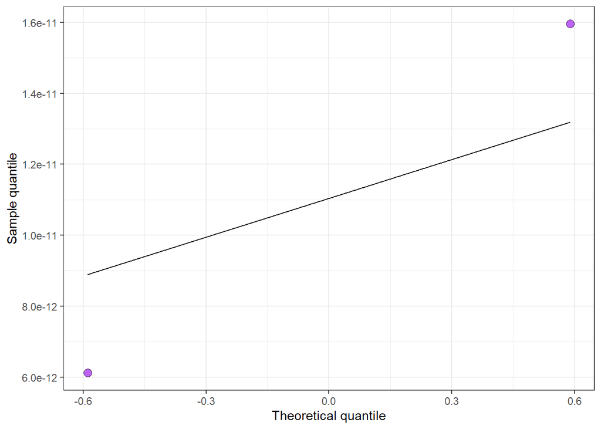

```r
#Random effect of fertilizer legacies
ranef(mod1_exp_0_5)[[1]] %>%
  ggplot(aes(sample=`(Intercept)`))+
  stat_qq(  shape = 21,
            fill = "purple",
            size = 3,
            alpha = .7
  )+
  stat_qq_line()+
  labs(x = "Theoretical quantile",
       y = "Sample quantile")+
  theme_bw()
```

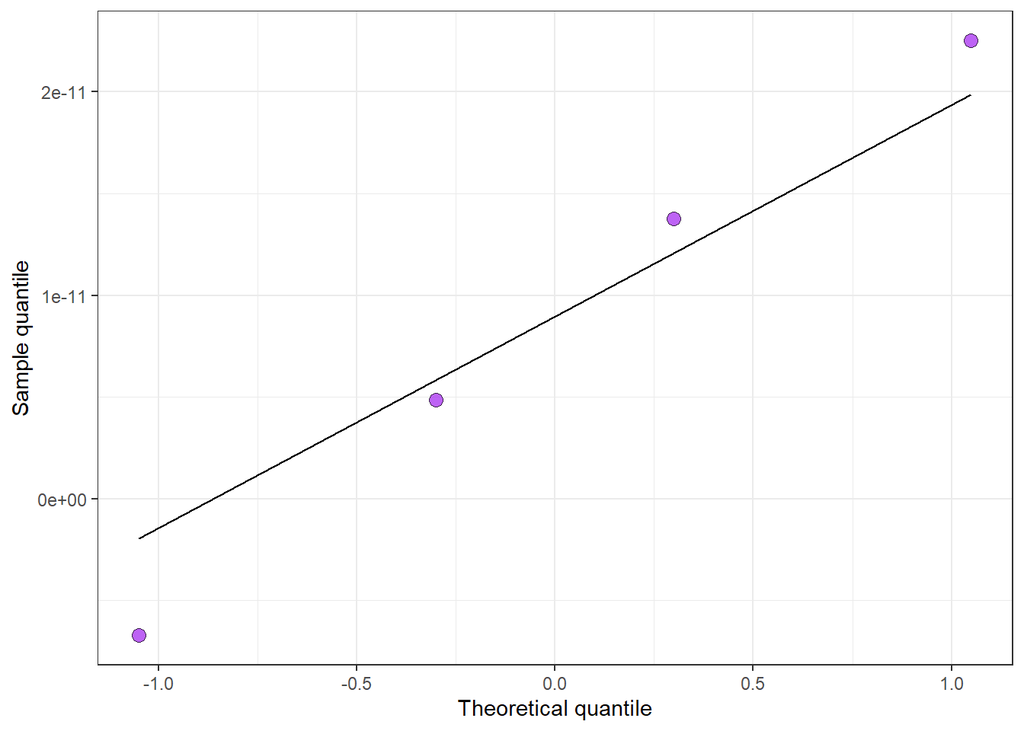

```r
#Fertilizer legacy:Soil drainage type interaction
ranef(mod1_exp_0_5)[[2]] %>%
  ggplot(aes(sample=`(Intercept)`))+
  stat_qq(  shape = 21,
            fill = "purple",
            size = 3,
            alpha = .7
  )+
  stat_qq_line()+
  labs(x = "Theoretical quantile",
       y = "Sample quantile")+
  theme_bw()
```

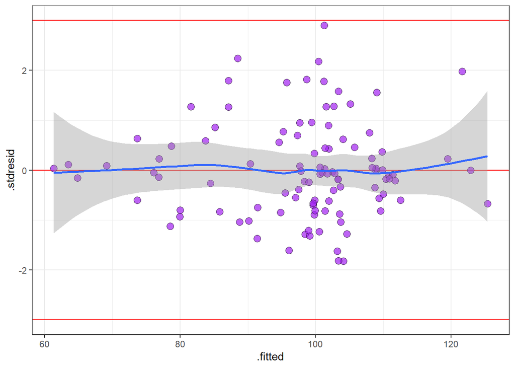

```r
# Checking if within group errors are iid ~ N(0, var_e)

ggplot(mod1_exp_resid_0_5, aes(x=.fitted, y=.stdresid))+
  geom_hline(yintercept = 0, color="red")+
  geom_point(shape = 21,
             fill = "purple",
             size = 3,
             alpha = .7)+
  geom_smooth()+
  geom_hline(yintercept = c(-3,3), color = "red")+
  theme_bw()
```

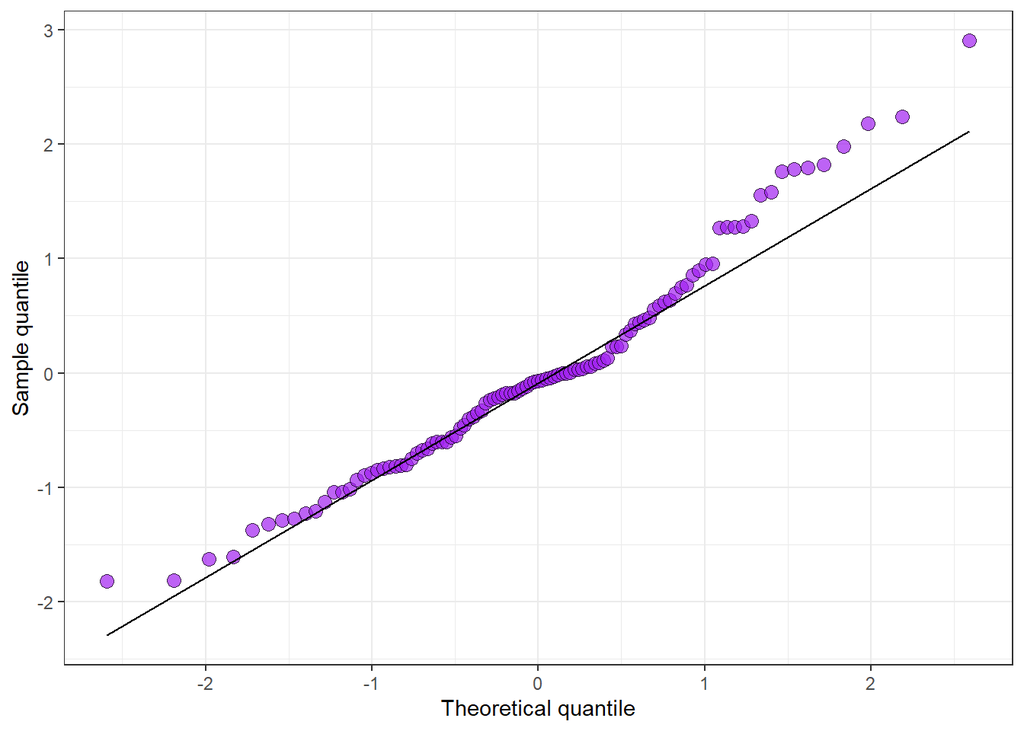

```r
ggplot(mod1_exp_resid_0_5, aes(sample=.stdresid))+
  stat_qq(  shape = 21,
            fill = "purple",
            size = 3,
            alpha = .7
  )+
  stat_qq_line()+
  labs(x = "Theoretical quantile",
       y = "Sample quantile")+
  theme_bw()
```

Since the random effect of fertilizer legacy and the fertilizer legacy: soil drainage type are independently identically distributed. The residuals of the between group effect were normal (only two points as seen in figure) and similar results were seen for the within group effects with four points for the four groups for FL:SDT interaction. The fitted vs standarized residuals plot does not show a clear pattern and no potential outliers are seen.The residuals also are iid hence we will proceed with Anova. Following chunk includes codes to run type-3 Anova to compare the means of the different groups for the 0-5 cm soil depth.

```r
Anova(mod1_exp_0_5, type = 3)
```

```
Analysis of Deviance Table (Type III tests)

Response: x0_5_loi_g_kg
             Chisq Df Pr(>Chisq)
(Intercept) 0.0715  1     0.7891
SDT         1.5975  1     0.2063
FL          0.0006  1     0.9804
X           1.1517  1     0.2832
Y           0.1480  1     0.7005
SDT:FL      0.4166  1     0.5186
SDT:X       1.5980  1     0.2062
FL:X        0.0006  1     0.9807
SDT:FL:X    0.4170  1     0.5184
```

Results of the Anova shows no significance for fertilizer legacy, soil drainage type, and the interaction. Hence we have not made comparison of the means for the groups individually of with interaction.

```r
mod2_sph_resid_10_20<- augment(mod2_sph_10_20) %>%
  mutate(.stdresid=resid(mod2_sph_10_20, type="pearson", scaled=T))
mod2_sph_resid_10_20
```

```
# A tibble: 105 × 15
   x0_5_loi_g_kg x5_10_loi_g_kg x10_20_loi_g_kg x20_40_loi_g_kg x40_60_loi_g_kg
           <dbl>          <dbl>           <dbl>           <dbl>           <dbl>
 1         120.            83.7            73.4            83.7            91.9
 2         109.            75.6            62.4            58.7            69.6
 3         107.            74.0            66.1            66.4            81.2
 4         123.            80.8            72.1            77.7            96.0
 5         108.            75.0            66.0            64.0            65.3
 6         106.            86.8            83.6            87.1           102.
 7         110.            78.9            72.4            65.5            72.4
 8          94.2           74.0            68.8            61.2            63.9
 9         110.            83.4            66.1            70.7            86.1
10         106.            69.2            63.6           104.             95.0
# ℹ 95 more rows
# ℹ 10 more variables: x60_90_loi_g_kg <dbl>, SDT <fct>, FL <fct>, X <dbl>,
#   Y <dbl>, geometry <POINT [m]>, .fitted <dbl>, .resid <dbl>, .fixed <dbl>,
#   .stdresid <dbl>
```

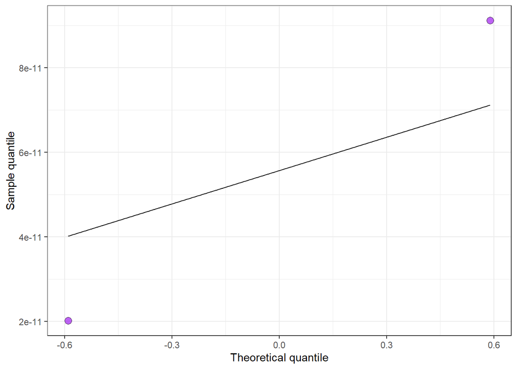

```r
#Random effect of fertilizer legacies
ranef(mod2_sph_10_20)[[1]] %>%
  ggplot(aes(sample=`(Intercept)`))+
  stat_qq(  shape = 21,
            fill = "purple",
            size = 3,
            alpha = .7
  )+
  stat_qq_line()+
  labs(x = "Theoretical quantile",
       y = "Sample quantile")+
  theme_bw()
```

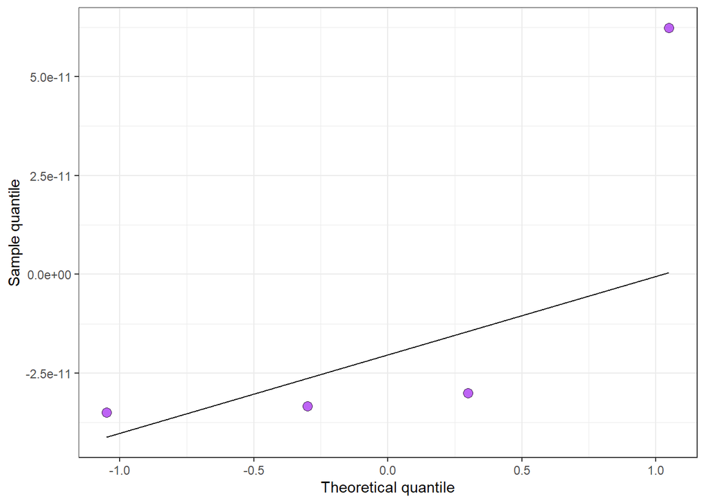

```r
#Fertilizer legacy:Soil drainage type interaction
ranef(mod2_sph_10_20)[[2]] %>%
  ggplot(aes(sample=`(Intercept)`))+
  stat_qq(  shape = 21,
            fill = "purple",
            size = 3,
            alpha = .7
  )+
  stat_qq_line()+
  labs(x = "Theoretical quantile",
       y = "Sample quantile")+
  theme_bw()
```

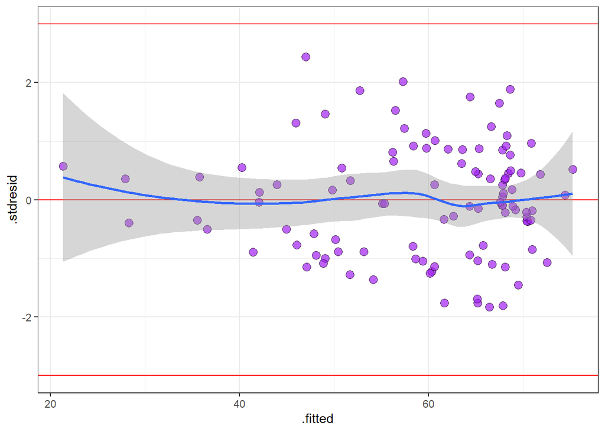

```r
# Checking if within group errors are iid ~ N(0, var_e)

ggplot(mod2_sph_resid_10_20, aes(x=.fitted, y=.stdresid))+
  geom_hline(yintercept = 0, color="red")+
  geom_point(shape = 21,
             fill = "purple",
             size = 3,
             alpha = .7)+
  geom_smooth()+
  geom_hline(yintercept = c(-3,3), color = "red")+
  theme_bw()
```

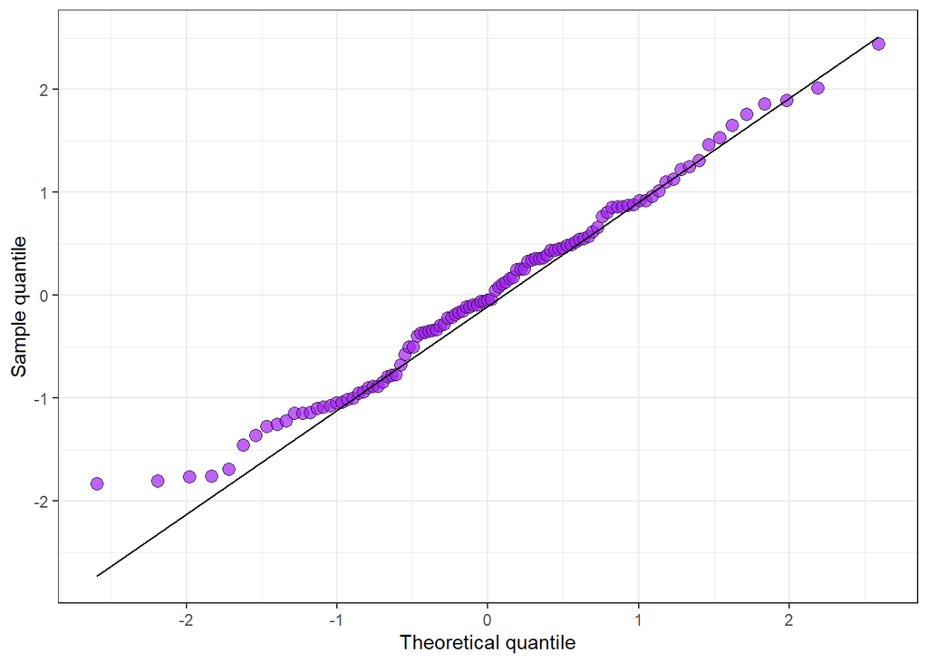

```r
ggplot(mod2_sph_resid_10_20, aes(sample=.stdresid))+
  stat_qq(  shape = 21,
            fill = "purple",
            size = 3,
            alpha = .7
  )+
  stat_qq_line()+
  labs(x = "Theoretical quantile",
       y = "Sample quantile")+
  theme_bw()
```

Similar results were observed for the spherical spatial correlation structure model for the 10-20 cm. The between group and within group effects are iid and the residuals are iid as well so we will proceed with the Anova to compare the means. In the following chunk, we run the type-3 Anova to compare means between the different groups at 10-20 cm soil depth.

```r
Anova(mod2_sph_10_20, type = 3)
```

```
Analysis of Deviance Table (Type III tests)

Response: x10_20_loi_g_kg
             Chisq Df Pr(>Chisq)
(Intercept) 3.5362  1   0.060044 .
SDT         9.0158  1   0.002677 **
FL          2.6088  1   0.106273
X           8.3940  1   0.003765 **
Y           4.7954  1   0.028536 *
SDT:FL      7.9292  1   0.004864 **
SDT:X       9.0163  1   0.002676 **
FL:X        2.6082  1   0.106313
SDT:FL:X    7.9302  1   0.004862 **
---
Signif. codes:  0 '***' 0.001 '**' 0.01 '*' 0.05 '.' 0.1 ' ' 1
```

Results on Anova shows significant effects of the easting and northing locations on the LOI carbon concentration of soils at 10-20 cm depth.

```r
sph_10_20_XY_means <- data_dfw %>%
  group_by(X, Y) %>%
  summarise(mean_loi_10_20 = mean(x10_20_loi_g_kg ))
```

[output not shown]

```r
sph_10_20_XY_means
```

```
Simple feature collection with 105 features and 3 fields
Geometry type: POINT
Dimension:     XY
Bounding box:  xmin: 269598.6 ymin: 3700276 xmax: 270001.3 ymax: 3700676
Projected CRS: WGS 84 / UTM zone 17N
# A tibble: 105 × 4
# Groups:   X [105]
         X        Y mean_loi_10_20           geometry
     <dbl>    <dbl>          <dbl>        <POINT [m]>
 1 269599. 3700522.           63.6 (269598.6 3700522)
 2 269610. 3700499.           66.0 (269610.1 3700499)
 3 269613. 3700532.           63.6 (269612.5 3700532)
 4 269622. 3700479.           73.4 (269621.8 3700479)
 5 269627. 3700512.           83.6 (269626.9 3700512)
 6 269632. 3700546.           64.9 (269632.1 3700546)
 7 269646. 3700527.           72.4 (269646.4 3700527)
 8 269661. 3700508.           62.4 (269660.8 3700508)
 9 269666. 3700542.           68.8   (269666 3700542)
10 269674. 3700585.           67.4 (269674.4 3700585)
# ℹ 95 more rows
```

```r
library(emmeans)
rm_loi_10_20_sph <- emmeans(mod2_sph_10_20, ~X + Y| SDT : FL ) %>%
  as.data.frame()
rm_loi_10_20_sph
```

```
SDT = MWD, FL = BL:
        X       Y   emmean       SE df lower.CL upper.CL
 269807.9 3700501 56.77912 12.92817  0      NaN      NaN

SDT = WD, FL = BL:
        X       Y   emmean       SE df lower.CL upper.CL
 269807.9 3700501 55.25728 12.32601  0      NaN      NaN

SDT = MWD, FL = MF:
        X       Y   emmean       SE df lower.CL upper.CL
 269807.9 3700501 53.44207 14.48576  0      NaN      NaN

SDT = WD, FL = MF:
        X       Y   emmean       SE df lower.CL upper.CL
 269807.9 3700501 69.63163 12.40564  0      NaN      NaN

Degrees-of-freedom method: containment
Confidence level used: 0.95
```

```r
mod0_10_20_emmeans <- emmeans(mod0_10_20,~ SDT * FL * X + Y + (1 | FL) + (1 | SDT))%>%
  as.data.frame()
mod0_10_20_emmeans
```

```
 SDT FL        X       Y   emmean       SE df lower.CL upper.CL
 MWD BL 269807.9 3700501 58.04381 54.91840  0      NaN      NaN
 WD  BL 269807.9 3700501 54.74966 54.54947  0      NaN      NaN
 MWD MF 269807.9 3700501 52.73223      NaN  0      NaN      NaN
 WD  MF 269807.9 3700501 69.58836      NaN  0      NaN      NaN

Degrees-of-freedom method: kenward-roger
Confidence level used: 0.95
```

```r
validation <- cbind(mod0_10_20_emmeans,rm_loi_10_20_sph) #%>%
  #rename(emmenas_def=emmean.1) %>%
  #rename(SE_def= SE.1) %>%
  #dplyr::select(X,Y,SDT,FL, emmean ,SE,emmean.1,SE.1)
validation
```

```
  SDT FL        X       Y   emmean       SE            df lower.CL upper.CL
1 MWD BL 269807.9 3700501 58.04381 54.91840 -0.0004529417      NaN      NaN
2  WD BL 269807.9 3700501 54.74966 54.54947 -0.0002862843      NaN      NaN
3 MWD MF 269807.9 3700501 52.73223      NaN  0.0010838231      NaN      NaN
4  WD MF 269807.9 3700501 69.58836      NaN -0.0001438916      NaN      NaN
         X       Y SDT FL   emmean       SE df lower.CL upper.CL
1 269807.9 3700501 MWD BL 56.77912 12.92817  0      NaN      NaN
2 269807.9 3700501  WD BL 55.25728 12.32601  0      NaN      NaN
3 269807.9 3700501 MWD MF 53.44207 14.48576  0      NaN      NaN
4 269807.9 3700501  WD MF 69.63163 12.40564  0      NaN      NaN
```

# 7 Team work in GitHub

Whether you are working with your future-self or as duos, make sure to stage, commit, and push after finishing each of the sub-sections above. When committing, write commit messages that are short and descriptive (e.g., finished wrangling).

If you are working in duos, make sure to split the workload. I will check your collaborative work through the commit history, and if one student has contributed significantly more than the other, than that will impact grades.

**Tip 1**: to avoid merge conflicts, make sure to **pull** first, and then start working locally. That will ensure that any changes made by your partner will be “downloaded” before you make changes to the files locally.

**Tip 2**: make use of the Issues on this repository to set up to-do lists and assign tasks to different people. You can also use each issue/task to discuss how things should be run and get to an agreement.

# 8 Submitting your work

Once you have developed all the code and answers, make sure to Render this quarto file.

**Notes on rendering**:

- Make sure to render your work and inspect how the final html look like.
- If it does not look professional for whatever reason, then fix the issue, re-render it, recheck.
- Only send me your work once your html file looks professional.
- Some potential issues you may encounter and how to fix them:
  - Some times your code may be creating a table output that is waaay to long and cumbersome to scroll through when rendered. If this is the case, make it more professional looking by using the `head()` function to only print the first handful of rows (instead of thousands of rows).
  - **DO NOT** delete the file’s heading levels (# and ##). They set up the proper heading 1 and 2 levels, and I use them to guide my grading.
  - If a given chunk is also outputting warnings or messages, inhibit this behavior by changing the chunk options `message` and `warning` to `FALSE`.
  - If, after rendered, 2 lines of text are connected and you wish to “break line” between them, add 2 extra spaces after the first one.

After rendering, an .html file will be created on your `code` folder.

Rename this file to `LASTNAME1-LASTNAME2_midtermproject.html`.  
For ex., `Bastos-Mendes_midtermproject.html`.

Send the html file to my email (lmbastos@uga.edu) by **April 11th** 11:59 pm.